# **Tugas Akhir TPG**

Nyoman Kiranasassi Anara G1401231028

## A. Input Data

```python
import pandas as pd

# 1. Load the 0_df_long.csv file into a pandas DataFrame, specifying semicolon as separator
df = pd.read_csv('/content/0_df_long.csv', sep=';')

# Create a mapping for Indonesian month names to English month numbers
month_mapping = {
    'Januari': '01',
    'Februari': '02',
    'Maret': '03',
    'April': '04',
    'Mei': '05',
    'Juni': '06',
    'Juli': '07',
    'Agustus': '08',
    'September': '09',
    'Oktober': '10',
    'November': '11',
    'Desember': '12'
}

# Apply the mapping to the 'Bulan' column
df['Bulan_Numeric'] = df['Bulan'].map(month_mapping)

# 2. Create a new column named 'tanggal' by combining 'Tahun' and 'Bulan_Numeric' into a datetime object with explicit format
df['tanggal'] = pd.to_datetime(df['Tahun'].astype(str) + '-' + df['Bulan_Numeric'].astype(str) + '-01', format='%Y-%m-%d')

# 3. Convert the 'Harga' column to a numeric data type, coercing non-numeric values to NaN
df['Harga'] = pd.to_numeric(df['Harga'], errors='coerce')

print("DataFrame loaded and processed. First 5 rows:")
print(df.head())
print("\nDataFrame Info:")
df.info()
```

```
DataFrame loaded and processed. First 5 rows:
            KabKot  Tahun    Bulan                  Produk    Harga Kategori  \
0  Kab. Aceh Barat   2022  Januari           Beras Premium  11429.0    Beras
1  Kab. Aceh Barat   2022  Januari            Beras Medium   9979.0    Beras
2  Kab. Aceh Barat   2022  Januari            Bawang Merah  31000.0   Bawang
3  Kab. Aceh Barat   2022  Januari  Bawang Putih (Bonggol)  28636.0   Bawang
4  Kab. Aceh Barat   2022  Januari    Cabai Merah Keriting  19409.0    Cabai

   KodeBPS  KodeProv NamaProv Bulan_Numeric    tanggal
0    11.05        11     Aceh            01 2022-01-01
1    11.05        11     Aceh            01 2022-01-01
2    11.05        11     Aceh            01 2022-01-01
3    11.05        11     Aceh            01 2022-01-01
4    11.05        11     Aceh            01 2022-01-01

DataFrame Info:
<class 'pandas.core.frame.DataFrame'>
RangeIndex: 340620 entries, 0 to 340619
Data columns (total 11 columns):
 #   Column         Non-Null Count   Dtype
---  ------         --------------   -----
 0   KabKot         340620 non-null  object
 1   Tahun          340620 non-null  int64
 2   Bulan          340620 non-null  object
 3   Produk         340620 non-null  object
 4   Harga          279107 non-null  float64
 5   Kategori       340620 non-null  object
 6   KodeBPS        340620 non-null  float64
 7   KodeProv       340620 non-null  int64
 8   NamaProv       337170 non-null  object
 9   Bulan_Numeric  340620 non-null  object
 10  tanggal        340620 non-null  datetime64[ns]
dtypes: datetime64[ns](1), float64(2), int64(2), object(6)
memory usage: 28.6+ MB
```

### Filtering dan Merging Data

Filter berdasarkan Kategori Protein: Daging Sapi Murni, Daging Ayam Ras, Telur Ayam Ras Filter wilayah: Banten, DKI Jakarta, Jawa Barat, Jawa Tengah, DI Yogyakarta, Jawa Timur Merging: Data latitude dan longitude untuk sekitar daerah yang akan diinterpolasi untuk missing value

```python
print("Unique values in 'Kategori' column:")
print(df['Kategori'].unique())
```

```
Unique values in 'Kategori' column:
['Beras' 'Bawang' 'Cabai' 'Protein' 'Gula' 'MinyakGoreng' 'Jagung']
```

## Explore Missing Values in Filtered Data

```python
import pandas as pd

print("### Exploring Missing Values in df_filtered_provinces (Harga column) ###\n")

# 1. Calculate the total number of missing values in the 'Harga' column
total_missing_harga = df_filtered_provinces['Harga'].isnull().sum()
print(f"Total missing values in 'Harga' column: {total_missing_harga}\n")

# 2. Group by 'Produk' and count missing 'Harga' values
missing_by_produk = df_filtered_provinces.groupby('Produk')['Harga'].apply(lambda x: x.isnull().sum())
print("Missing values in 'Harga' by 'Produk':\n")
print(missing_by_produk)
print("\n")

# 3. Group by 'NamaProv' and count missing 'Harga' values
missing_by_namaprov = df_filtered_provinces.groupby('NamaProv')['Harga'].apply(lambda x: x.isnull().sum())
print("Missing values in 'Harga' by 'NamaProv':\n")
print(missing_by_namaprov)
print("\n")

# 4. Group by both 'NamaProv' and 'Produk' and count missing 'Harga' values
missing_by_prov_produk = df_filtered_provinces.groupby(['NamaProv', 'Produk'])['Harga'].apply(lambda x: x.isnull().sum())
print("Missing values in 'Harga' by 'NamaProv' and 'Produk':\n")
print(missing_by_prov_produk)
```

```
### Exploring Missing Values in df_filtered_provinces (Harga column) ###

Total missing values in 'Harga' column: 83

Missing values in 'Harga' by 'Produk':

Produk
Daging Ayam Ras      29
Daging Sapi Murni    54
Telur Ayam Ras        0
Name: Harga, dtype: int64


Missing values in 'Harga' by 'NamaProv':

NamaProv
Banten            0
DI Yogyakarta     0
DKI Jakarta      64
Jawa Barat        1
Jawa Tengah       0
Jawa Timur       18
Name: Harga, dtype: int64


Missing values in 'Harga' by 'NamaProv' and 'Produk':

NamaProv       Produk
Banten         Daging Ayam Ras       0
               Daging Sapi Murni     0
               Telur Ayam Ras        0
DI Yogyakarta  Daging Ayam Ras       0
               Daging Sapi Murni     0
               Telur Ayam Ras        0
DKI Jakarta    Daging Ayam Ras      20
               Daging Sapi Murni    44
               Telur Ayam Ras        0
Jawa Barat     Daging Ayam Ras       0
               Daging Sapi Murni     1
               Telur Ayam Ras        0
Jawa Tengah    Daging Ayam Ras       0
               Daging Sapi Murni     0
               Telur Ayam Ras        0
Jawa Timur     Daging Ayam Ras       9
               Daging Sapi Murni     9
               Telur Ayam Ras        0
Name: Harga, dtype: int64
```

## Visualize Price Distribution by Product and Province

```
### Visualizing Price Distribution and Average Prices by Product and Province ###


--- Visualizing Price Distribution for: Daging Sapi Murni ---
```

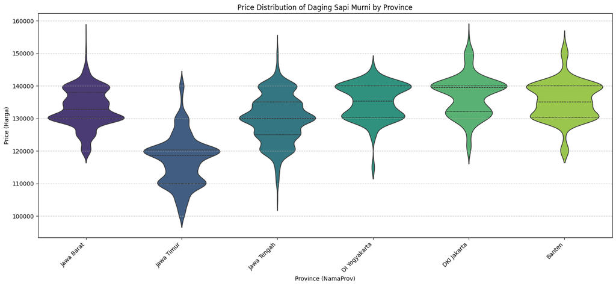

```
--- Visualizing Price Distribution for: Daging Ayam Ras ---
```

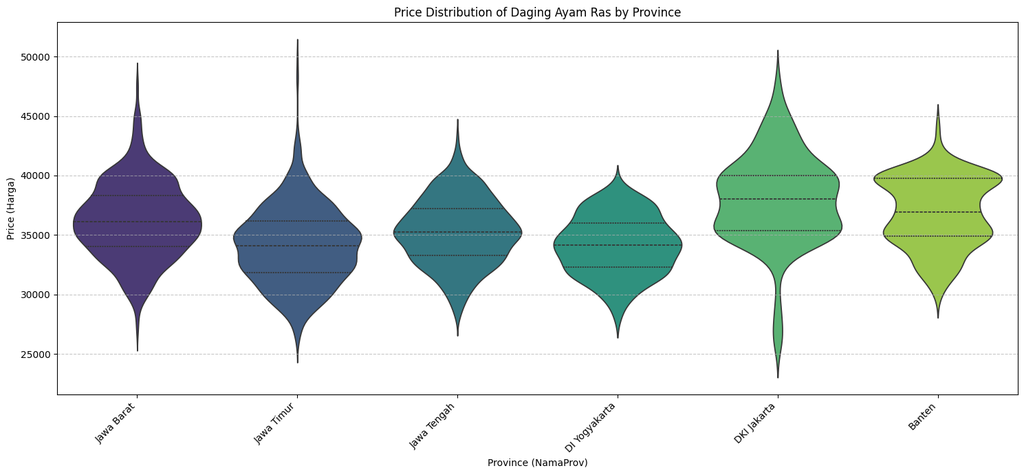

```
--- Visualizing Price Distribution for: Telur Ayam Ras ---
```

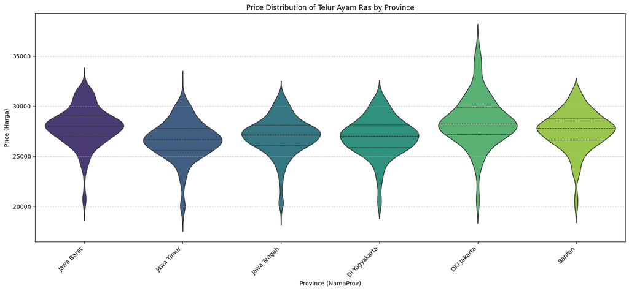

```
--- Visualizing Average Prices of Protein Products by Province ---
```

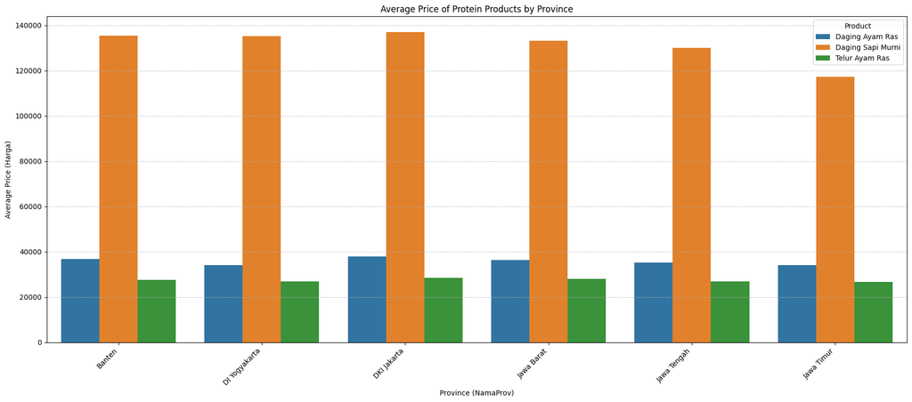

```
All price distribution and average price visualizations completed.
```

```python
import matplotlib.pyplot as plt
import seaborn as sns
import pandas as pd

print("### Visualizing Price Distribution and Average Prices by Product and Province ###\n")

# 1. Create a list of the unique protein products from the df_result DataFrame
protein_products = df_result['Produk'].unique()

# 2. For each product in the list: generate distribution plots
for product in protein_products:
    print(f"\n--- Visualizing Price Distribution for: {product} ---")
    # a. Filter df_result to get data for the current product
    df_product_filtered = df_result[df_result['Produk'] == product]

    # b. Create a violin plot to visualize the distribution of 'Harga' across different 'NamaProv'
    plt.figure(figsize=(15, 7))
    sns.violinplot(x='NamaProv', y='Harga', hue='NamaProv', data=df_product_filtered, inner='quartile', palette='viridis', legend=False)
    plt.title(f'Price Distribution of {product} by Province')
    plt.xlabel('Province (NamaProv)')
    plt.ylabel('Price (Harga)')
    plt.xticks(rotation=45, ha='right')
    plt.grid(axis='y', linestyle='--', alpha=0.7)
    plt.tight_layout()
    plt.show()

# 3. Calculate the average 'Harga' for each product across all provinces
print("\n--- Visualizing Average Prices of Protein Products by Province ---")
# Group by 'NamaProv' and 'Produk', then calculate the mean 'Harga'
average_prices_by_prov_product = df_result.groupby(['NamaProv', 'Produk'])['Harga'].mean().reset_index()

# 4. Create a bar plot to visualize these average prices
plt.figure(figsize=(18, 8))
sns.barplot(x='NamaProv', y='Harga', hue='Produk', data=average_prices_by_prov_product, palette='tab10')
plt.title('Average Price of Protein Products by Province')
plt.xlabel('Province (NamaProv)')
plt.ylabel('Average Price (Harga)')
plt.xticks(rotation=45, ha='right')
plt.legend(title='Product')
plt.grid(axis='y', linestyle='--', alpha=0.7)
plt.tight_layout()
plt.show()

print("\nAll price distribution and average price visualizations completed.")
```

```python
import pandas as pd

# 1. Filter the df DataFrame to include only specified protein categories
# Update protein_categories based on actual values in 'Kategori' column
protein_categories = ['Protein']
df_filtered = df[df['Kategori'].isin(protein_categories)].copy()

# Check if df_filtered is empty and print a warning if so
if df_filtered.empty:
    print("Warning: df_filtered is empty even after correcting protein categories. This might indicate an issue with the data or further category mismatches.")

# 2. Create the coord_jawa DataFrame directly from the provided data
coord_jawa = pd.DataFrame({
    'KabKot': [
        'Kab. Kepulauan Seribu', 'Jakarta Utara', 'Kab. Bekasi', 'Kab. Karawang', 'Kab. Subang',
        'Kab. Indramayu', 'Kab. Purwakarta', 'Kab. Magetan', 'Kota Madiun',
        'Kab. Madiun', 'Kab. Ngawi', 'Kab. Ponorogo', 'Kab. Nganjuk', 'Kab. Wonogiri'
    ],
    'NamaProv': [
        'DKI Jakarta', 'DKI Jakarta', 'Jawa Barat', 'Jawa Barat', 'Jawa Barat',
        'Jawa Barat', 'Jawa Barat', 'Jawa Timur', 'Jawa Timur',
        'Jawa Timur', 'Jawa Timur', 'Jawa Timur', 'Jawa Timur', 'Jawa Tengah'
    ],
    'longitude': [
        106.5575, 106.8000, 107.1300, 107.3000, 107.7500,
        108.3200, 107.4500, 111.3500, 111.5200,
        111.5100, 111.3600, 111.4700, 111.9000, 111.0500
    ],
    'latitude': [
        -5.7375, -6.1200, -6.2500, -6.3000, -6.5700,
        -6.3300, -6.5500, -7.6400, -7.6300,
        -7.6200, -7.4200, -7.8700, -7.6100, -7.9900
    ]
})

# 3. Merge the df_filtered DataFrame with the coord_jawa DataFrame on 'KabKot'
df_merged = pd.merge(df_filtered, coord_jawa, on='KabKot', how='inner')

print("Filtered and merged DataFrame. First 5 rows:")
print(df_merged.head())
print("\nDataFrame Info:")
df_merged.info()
print(df_merged['KabKot'].unique())
```

```
Filtered and merged DataFrame. First 5 rows:
        KabKot  Tahun     Bulan             Produk     Harga Kategori  \
0  Kab. Bekasi   2022   Januari  Daging Sapi Murni  130000.0  Protein
1  Kab. Bekasi   2022   Januari    Daging Ayam Ras   39200.0  Protein
2  Kab. Bekasi   2022   Januari     Telur Ayam Ras   25400.0  Protein
3  Kab. Bekasi   2022  Februari  Daging Sapi Murni  130357.0  Protein
4  Kab. Bekasi   2022  Februari    Daging Ayam Ras   40000.0  Protein

   KodeBPS  KodeProv  NamaProv_x Bulan_Numeric    tanggal  NamaProv_y  \
0    32.16        32  Jawa Barat            01 2022-01-01  Jawa Barat
1    32.16        32  Jawa Barat            01 2022-01-01  Jawa Barat
2    32.16        32  Jawa Barat            01 2022-01-01  Jawa Barat
3    32.16        32  Jawa Barat            02 2022-02-01  Jawa Barat
4    32.16        32  Jawa Barat            02 2022-02-01  Jawa Barat

   longitude  latitude
0     107.13     -6.25
1     107.13     -6.25
2     107.13     -6.25
3     107.13     -6.25
4     107.13     -6.25

DataFrame Info:
<class 'pandas.core.frame.DataFrame'>
RangeIndex: 1794 entries, 0 to 1793
Data columns (total 14 columns):
 #   Column         Non-Null Count  Dtype
---  ------         --------------  -----
 0   KabKot         1794 non-null   object
 1   Tahun          1794 non-null   int64
 2   Bulan          1794 non-null   object
 3   Produk         1794 non-null   object
 4   Harga          1711 non-null   float64
 5   Kategori       1794 non-null   object
 6   KodeBPS        1794 non-null   float64
 7   KodeProv       1794 non-null   int64
 8   NamaProv_x     1794 non-null   object
 9   Bulan_Numeric  1794 non-null   object
 10  tanggal        1794 non-null   datetime64[ns]
 11  NamaProv_y     1794 non-null   object
 12  longitude      1794 non-null   float64
 13  latitude       1794 non-null   float64
dtypes: datetime64[ns](1), float64(4), int64(2), object(7)
memory usage: 196.3+ KB
['Kab. Bekasi' 'Kab. Indramayu' 'Kab. Karawang' 'Kab. Kepulauan Seribu'
 'Kab. Madiun' 'Kab. Magetan' 'Kab. Nganjuk' 'Kab. Ngawi' 'Kab. Ponorogo'
 'Kab. Purwakarta' 'Kab. Subang' 'Kab. Wonogiri' 'Kota Madiun']
```

## Imputasi Data

```
### Re-performing Interpolation Steps ###

Initial temporal interpolation applied to all KabKot-Produk series.

Total remaining NaNs in 'Harga' column after all interpolations: 10

### Visualizing Before and After Interpolation ###
```

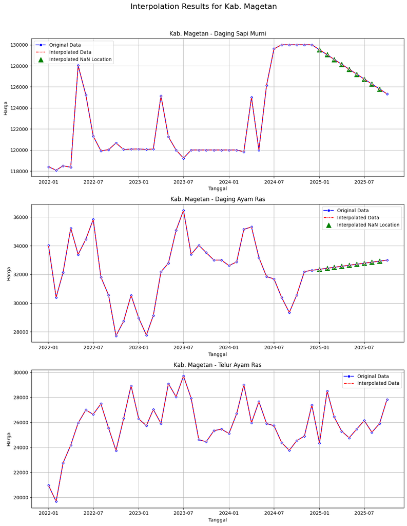

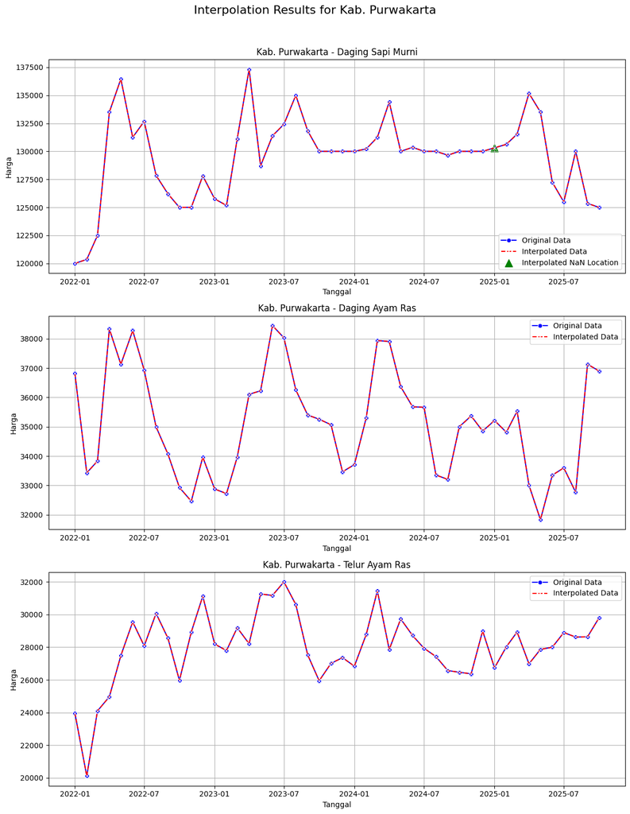

```
All interpolations re-applied and visualizations generated.
```

```python
from math import radians, sin, cos, sqrt, atan2
import numpy as np
import pandas as pd
import matplotlib.pyplot as plt
import seaborn as sns

# Function to calculate Haversine distance between two lat/lon points (re-defined for self-containment)
def haversine_distance(lat1, lon1, lat2, lon2):
    R = 6371  # Radius of Earth in kilometers

    lat1, lon1, lat2, lon2 = map(radians, [lat1, lon1, lat2, lon2])

    dlon = lon2 - lon1
    dlat = lat2 - lat1

    a = sin(dlat / 2)**2 + cos(lat1) * cos(lat2) * sin(dlon / 2)**2
    c = 2 * atan2(sqrt(a), sqrt(1 - a))

    distance = R * c
    return distance

print("### Re-performing Interpolation Steps ###\n")

# --- Step 1: Create a fresh working copy and apply initial temporal interpolation ---
df_working_copy = df_merged.copy()
df_working_copy.sort_values(by=['KabKot', 'Produk', 'tanggal'], inplace=True)
df_working_copy['Harga'] = df_working_copy.groupby(['KabKot', 'Produk'])['Harga'].transform(lambda group: group.interpolate(method='linear'))

print("Initial temporal interpolation applied to all KabKot-Produk series.")

# --- Step 2: Spatial Interpolation for Kab. Magetan (if any NaNs remain) ---
magetan_missing_rows_indices = df_working_copy[(df_working_copy['KabKot'] == 'Kab. Magetan') & (df_working_copy['Harga'].isnull())].index

if not magetan_missing_rows_indices.empty:
    print(f"Applying spatial interpolation for {len(magetan_missing_rows_indices)} remaining NaNs in Kab. Magetan...")
    coords = df_merged[['KabKot', 'latitude', 'longitude']].drop_duplicates().set_index('KabKot')
    for idx in magetan_missing_rows_indices:
        row = df_working_copy.loc[idx]
        target_date = row['tanggal']
        target_product = row['Produk']
        target_lat = coords.loc['Kab. Magetan']['latitude']
        target_lon = coords.loc['Kab. Magetan']['longitude']

        possible_neighbors = df_working_copy[
            (df_working_copy['tanggal'] == target_date) &
            (df_working_copy['Produk'] == target_product) &
            (df_working_copy['KabKot'] != 'Kab. Magetan') &
            (df_working_copy['Harga'].notnull())
        ].copy()

        if not possible_neighbors.empty:
            distances = []
            for _, neighbor_row in possible_neighbors.iterrows():
                neighbor_kabkot = neighbor_row['KabKot']
                if neighbor_kabkot in coords.index:
                    neighbor_lat = coords.loc[neighbor_kabkot]['latitude']
                    neighbor_lon = coords.loc[neighbor_kabkot]['longitude']
                    dist = haversine_distance(target_lat, target_lon, neighbor_lat, neighbor_lon)
                    distances.append(dist)
                else:
                    distances.append(np.inf)

            possible_neighbors['distance'] = distances
            possible_neighbors = possible_neighbors[possible_neighbors['distance'] != np.inf]

            if not possible_neighbors.empty:
                epsilon = 0.001
                weights = 1 / (possible_neighbors['distance'] + epsilon)
                sum_weights = weights.sum()

                if sum_weights > 0:
                    interpolated_harga = (possible_neighbors['Harga'] * weights).sum() / sum_weights
                    df_working_copy.loc[idx, 'Harga'] = interpolated_harga
                else:
                    df_working_copy.loc[idx, 'Harga'] = possible_neighbors['Harga'].mean()

# --- Step 3: Time Series Interpolation for Kab. Purwakarta (if any NaNs remain) ---
purwakarta_missing_rows_indices = df_working_copy[(df_working_copy['KabKot'] == 'Kab. Purwakarta') & (df_working_copy['Harga'].isnull())].index

if not purwakarta_missing_rows_indices.empty:
    print(f"Applying time series interpolation for {len(purwakarta_missing_rows_indices)} remaining NaNs in Kab. Purwakarta...")
    # Re-apply linear interpolation for Purwakarta, this time it should catch any stragglers
    df_working_copy['Harga'] = df_working_copy.groupby(['KabKot', 'Produk'])['Harga'].transform(lambda group: group.interpolate(method='linear'))



# --- Final check for NaNs ---
final_na_count = df_working_copy['Harga'].isnull().sum()
print(f"\nTotal remaining NaNs in 'Harga' column after all interpolations: {final_na_count}")

# --- Step 5: Visualize Before and After Interpolation ---
locations_to_visualize = ['Kab. Magetan', 'Kab. Purwakarta']

print("\n### Visualizing Before and After Interpolation ###\n")

for location in locations_to_visualize:
    df_original_loc = df_merged[df_merged['KabKot'] == location].copy()
    df_final_interpolated_loc = df_working_copy[df_working_copy['KabKot'] == location].copy()

    # Get unique products for the current location
    products_in_loc = df_original_loc['Produk'].unique()

    if df_original_loc.empty:
        fig, ax = plt.subplots(figsize=(12, 4))
        ax.text(0.5, 0.5, f"No data available for {location}",
                horizontalalignment='center', verticalalignment='center', transform=ax.transAxes,
                fontsize=14, color='gray')
        ax.set_title(f'Harga Time Series for {location} (No Data)')
        plt.show()
        continue

    fig, axes = plt.subplots(len(products_in_loc), 1, figsize=(12, 5 * len(products_in_loc)), squeeze=False)
    fig.suptitle(f'Interpolation Results for {location}', y=1.02, fontsize=16)

    for i, product in enumerate(products_in_loc):
        ax = axes[i, 0]

        original_product_data = df_original_loc[df_original_loc['Produk'] == product]
        final_product_data = df_final_interpolated_loc[df_final_interpolated_loc['Produk'] == product]

        # Plot original data points (non-NaN)
        sns.lineplot(x='tanggal', y='Harga', data=original_product_data.dropna(subset=['Harga']),
                     marker='o', linestyle='-', color='blue', label='Original Data', ax=ax)

        # Plot the final interpolated line
        sns.lineplot(x='tanggal', y='Harga', data=final_product_data,
                     marker='x', linestyle='--', color='red', label='Interpolated Data', ax=ax)

        # Mark original NaN positions explicitly
        missing_dates = original_product_data[original_product_data['Harga'].isnull()]['tanggal']
        if not missing_dates.empty:
            ax.scatter(missing_dates, final_product_data[final_product_data['tanggal'].isin(missing_dates)]['Harga'],
                       color='green', marker='^', s=100, label='Interpolated NaN Location')

        ax.set_title(f'{location} - {product}')
        ax.set_xlabel('Tanggal')
        ax.set_ylabel('Harga')
        ax.legend()
        ax.grid(True)

    plt.tight_layout()
    plt.show()

# Update the global df_interpolated with the final working copy
df_interpolated = df_working_copy.copy()

print("\nAll interpolations re-applied and visualizations generated.")
```

## IDW Interpolation for 'Kep. Seribu'

```
### Starting IDW Interpolation for Kab. Kepulauan Seribu ###

Found 64 missing 'Harga' values for 'Daging Ayam Ras' and 'Daging Sapi Murni' in 'Kep. Seribu'. Proceeding with IDW interpolation.

--- Visualizing Interpolation Results for Kab. Kepulauan Seribu ---
```

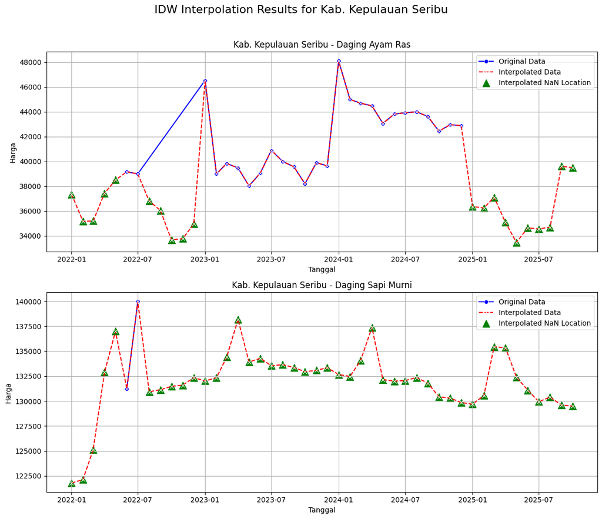

```
IDW Interpolation for Kab. Kepulauan Seribu completed and df_interpolated updated.
Final remaining NaNs in 'Kab. Kepulauan Seribu' for specified products: 0
```

```python
from math import radians, sin, cos, sqrt, atan2
import numpy as np
import pandas as pd
import matplotlib.pyplot as plt
import seaborn as sns

# Function to calculate Haversine distance (re-defined for self-containment)
def haversine_distance(lat1, lon1, lat2, lon2):
    R = 6371  # Radius of Earth in kilometers

    lat1, lon1, lat2, lon2 = map(radians, [lat1, lon1, lat2, lon2])

    dlon = lon2 - lon1
    dlat = lat2 - lat1

    a = sin(dlat / 2)**2 + cos(lat1) * cos(lat2) * sin(dlon / 2)**2
    c = 2 * atan2(sqrt(a), sqrt(1 - a))

    distance = R * c
    return distance

print("### Starting IDW Interpolation for Kab. Kepulauan Seribu ###\n")

# Create a working copy from df_merged to apply this specific interpolation
df_idw_kep_seribu_working = df_merged.copy()

# Filter for Kab. Kepulauan Seribu and the specified products
kep_seribu_products_to_interp = ['Daging Ayam Ras', 'Daging Sapi Murni']

# Check for missing values in Kep. Seribu for the specified products in df_merged
kep_seribu_data_original = df_idw_kep_seribu_working[
    (df_idw_kep_seribu_working['KabKot'] == 'Kab. Kepulauan Seribu') &
    (df_idw_kep_seribu_working['Produk'].isin(kep_seribu_products_to_interp))
]

missing_count_kep_seribu = kep_seribu_data_original['Harga'].isnull().sum()

if kep_seribu_data_original.empty:
    print("No data entries found for 'Kab. Kepulauan Seribu' with 'Daging Ayam Ras' or 'Daging Sapi Murni' in df_merged. Skipping IDW interpolation.")
elif missing_count_kep_seribu == 0:
    print("No missing 'Harga' values found for 'Daging Ayam Ras' and 'Daging Sapi Murni' in 'Kab. Kepulauan Seribu' in df_merged. Skipping IDW interpolation.")
else:
    print(f"Found {missing_count_kep_seribu} missing 'Harga' values for 'Daging Ayam Ras' and 'Daging Sapi Murni' in 'Kep. Seribu'. Proceeding with IDW interpolation.")

    # Get coordinates for all locations to calculate distances
    coords = df_merged[['KabKot', 'latitude', 'longitude']].drop_duplicates().set_index('KabKot')

    # Iterate through missing values in Kep. Seribu for the specified products
    # Use the original df_idw_kep_seribu_working for current values for neighbors, not the sliced one
    missing_rows_indices = df_idw_kep_seribu_working[
        (df_idw_kep_seribu_working['KabKot'] == 'Kab. Kepulauan Seribu') &
        (df_idw_kep_seribu_working['Produk'].isin(kep_seribu_products_to_interp)) &
        (df_idw_kep_seribu_working['Harga'].isnull())
    ].index

    for idx in missing_rows_indices:
        row = df_idw_kep_seribu_working.loc[idx]
        target_date = row['tanggal']
        target_product = row['Produk']

        if 'Kab. Kepulauan Seribu' in coords.index:
            target_lat = coords.loc['Kab. Kepulauan Seribu']['latitude']
            target_lon = coords.loc['Kab. Kepulauan Seribu']['longitude']
        else:
            print(f"Warning: Coordinates for Kab. Kepulauan Seribu not found. Skipping IDW for index {idx}.")
            continue

        # Find possible neighbors for the same date and product with non-null prices
        # Exclude 'Kep. Seribu' itself
        possible_neighbors = df_idw_kep_seribu_working[
            (df_idw_kep_seribu_working['tanggal'] == target_date) &
            (df_idw_kep_seribu_working['Produk'] == target_product) &
            (df_idw_kep_seribu_working['KabKot'] != 'Kab. Kepulauan Seribu') &
            (df_idw_kep_seribu_working['Harga'].notnull())
        ].copy()

        if not possible_neighbors.empty:
            distances = []
            for _, neighbor_row in possible_neighbors.iterrows():
                neighbor_kabkot = neighbor_row['KabKot']
                if neighbor_kabkot in coords.index:
                    neighbor_lat = coords.loc[neighbor_kabkot]['latitude']
                    neighbor_lon = coords.loc[neighbor_kabkot]['longitude']
                    dist = haversine_distance(target_lat, target_lon, neighbor_lat, neighbor_lon)
                    distances.append(dist)
                else:
                    distances.append(np.inf)

            possible_neighbors['distance'] = distances
            possible_neighbors = possible_neighbors[possible_neighbors['distance'] != np.inf]

            if not possible_neighbors.empty:
                epsilon = 0.001
                weights = 1 / (possible_neighbors['distance'] + epsilon)
                sum_weights = weights.sum()

                if sum_weights > 0:
                    interpolated_harga = (possible_neighbors['Harga'] * weights).sum() / sum_weights
                    df_idw_kep_seribu_working.loc[idx, 'Harga'] = interpolated_harga
                else:
                    df_idw_kep_seribu_working.loc[idx, 'Harga'] = possible_neighbors['Harga'].mean() # Fallback to mean
            else:
                print(f"No valid neighbors found for IDW at {target_date} for {target_product} in Kab. Kepulauan Seribu.")
        else:
            print(f"No non-null data for neighbors at {target_date} for {target_product} to perform IDW for Kep. Seribu.")

    print("\n--- Visualizing Interpolation Results for Kab. Kepulauan Seribu ---")
    fig, axes = plt.subplots(len(kep_seribu_products_to_interp), 1, figsize=(12, 5 * len(kep_seribu_products_to_interp)), squeeze=False)
    fig.suptitle('IDW Interpolation Results for Kab. Kepulauan Seribu', y=1.02, fontsize=16)

    for i, product in enumerate(kep_seribu_products_to_interp):
        ax = axes[i, 0]

        original_product_data = kep_seribu_data_original[kep_seribu_data_original['Produk'] == product]
        interpolated_product_data = df_idw_kep_seribu_working[
            (df_idw_kep_seribu_working['KabKot'] == 'Kab. Kepulauan Seribu') &
            (df_idw_kep_seribu_working['Produk'] == product)
        ]

        # Plot original data points (non-NaN)
        sns.lineplot(x='tanggal', y='Harga', data=original_product_data.dropna(subset=['Harga']),
                     marker='o', linestyle='-', color='blue', label='Original Data', ax=ax)

        # Plot the interpolated line
        sns.lineplot(x='tanggal', y='Harga', data=interpolated_product_data,
                     marker='x', linestyle='--', color='red', label='Interpolated Data', ax=ax)

        # Mark original NaN positions explicitly
        missing_dates = original_product_data[original_product_data['Harga'].isnull()]['tanggal']
        if not missing_dates.empty:
            ax.scatter(missing_dates, interpolated_product_data[interpolated_product_data['tanggal'].isin(missing_dates)]['Harga'],
                       color='green', marker='^', s=100, label='Interpolated NaN Location')

        ax.set_title(f'Kab. Kepulauan Seribu - {product}')
        ax.set_xlabel('Tanggal')
        ax.set_ylabel('Harga')
        ax.legend()
        ax.grid(True)

    plt.tight_layout()
    plt.show()

# Update df_interpolated with the new IDW interpolated values for Kep. Seribu
# This assumes df_interpolated was the result of previous full interpolations.
# We need to replace the Kep. Seribu parts in df_interpolated with these new ones.
# First, ensure df_interpolated is a copy to avoid SettingWithCopyWarning
df_interpolated_copy = df_interpolated.copy()

# Replace the rows for Kep. Seribu and specified products
# in df_interpolated_copy with the newly interpolated values from df_idw_kep_seribu_working

# Find indices to update in df_interpolated_copy
indices_to_update = df_interpolated_copy[
    (df_interpolated_copy['KabKot'] == 'Kab. Kepulauan Seribu') &
    (df_interpolated_copy['Produk'].isin(kep_seribu_products_to_interp))
].index

# Update these rows from df_idw_kep_seribu_working
df_interpolated_copy.loc[indices_to_update, 'Harga'] = df_idw_kep_seribu_working.loc[indices_to_update, 'Harga']

df_interpolated = df_interpolated_copy.copy()

print("\nIDW Interpolation for Kab. Kepulauan Seribu completed and df_interpolated updated.")

# Final check for NaNs in Kep. Seribu after update
final_missing_kep_seribu = df_interpolated[
    (df_interpolated['KabKot'] == 'Kab. Kepulauan Seribu') &
    (df_interpolated['Produk'].isin(kep_seribu_products_to_interp)) &
    (df_interpolated['Harga'].isnull())
]['Harga'].isnull().sum()

print(f"Final remaining NaNs in 'Kab. Kepulauan Seribu' for specified products: {final_missing_kep_seribu}")
```

## Merging Data yang sudah terimputasi ke df awal

```python
import pandas as pd

print("### DataFrame `df_interpolated` (First 5 Rows): ###\n")
display(df_interpolated.head())

print("\n### DataFrame `df_interpolated` Info: ###\n")
df_interpolated.info()
```

```
### DataFrame `df_interpolated` (First 5 Rows): ###
```

|  | KabKot | Tahun | Bulan | Produk | Harga | Kategori | KodeBPS | KodeProv | NamaProv_x | Bulan_Numeric | tanggal | NamaProv_y | longitude | latitude |
| --- | --- | --- | --- | --- | --- | --- | --- | --- | --- | --- | --- | --- | --- | --- |
| 1 | Kab. Bekasi | 2022 | Januari | Daging Ayam Ras | 39200.0 | Protein | 32.16 | 32 | Jawa Barat | 01 | 2022-01-01 | Jawa Barat | 107.13 | -6.25 |
| 4 | Kab. Bekasi | 2022 | Februari | Daging Ayam Ras | 40000.0 | Protein | 32.16 | 32 | Jawa Barat | 02 | 2022-02-01 | Jawa Barat | 107.13 | -6.25 |
| 7 | Kab. Bekasi | 2022 | Maret | Daging Ayam Ras | 40000.0 | Protein | 32.16 | 32 | Jawa Barat | 03 | 2022-03-01 | Jawa Barat | 107.13 | -6.25 |
| 10 | Kab. Bekasi | 2022 | April | Daging Ayam Ras | 43143.0 | Protein | 32.16 | 32 | Jawa Barat | 04 | 2022-04-01 | Jawa Barat | 107.13 | -6.25 |
| 13 | Kab. Bekasi | 2022 | Mei | Daging Ayam Ras | 47708.0 | Protein | 32.16 | 32 | Jawa Barat | 05 | 2022-05-01 | Jawa Barat | 107.13 | -6.25 |

```
### DataFrame `df_interpolated` Info: ###

<class 'pandas.core.frame.DataFrame'>
Index: 1794 entries, 1 to 1793
Data columns (total 14 columns):
 #   Column         Non-Null Count  Dtype
---  ------         --------------  -----
 0   KabKot         1794 non-null   object
 1   Tahun          1794 non-null   int64
 2   Bulan          1794 non-null   object
 3   Produk         1794 non-null   object
 4   Harga          1794 non-null   float64
 5   Kategori       1794 non-null   object
 6   KodeBPS        1794 non-null   float64
 7   KodeProv       1794 non-null   int64
 8   NamaProv_x     1794 non-null   object
 9   Bulan_Numeric  1794 non-null   object
 10  tanggal        1794 non-null   datetime64[ns]
 11  NamaProv_y     1794 non-null   object
 12  longitude      1794 non-null   float64
 13  latitude       1794 non-null   float64
dtypes: datetime64[ns](1), float64(4), int64(2), object(7)
memory usage: 274.8+ KB
```

```python
import pandas as pd

# Define the target category and provinces
target_category = 'Protein'
target_provinces = ['Banten', 'DKI Jakarta', 'DI Yogyakarta', 'Jawa Barat', 'Jawa Tengah', 'Jawa Timur']

# Filter the df DataFrame
df_filtered_provinces = df[
    (df['Kategori'] == target_category) &
    (df['NamaProv'].isin(target_provinces))
].copy()

print("### DataFrame setelah difilter untuk kategori 'Protein' dan provinsi-provinsi di Jawa: ###\n")
display(df_filtered_provinces.head())

print("\n### Informasi DataFrame df_filtered_provinces: ###\n")
df_filtered_provinces.info()

print("\nJumlah Kabupaten/Kota unik dalam df_filtered_provinces:")
display(df_filtered_provinces['KabKot'].unique())

print("\nJumlah Produk unik dalam df_filtered_provinces:")
display(df_filtered_provinces['Produk'].unique())
```

```
### DataFrame setelah difilter untuk kategori 'Protein' dan provinsi-provinsi di Jawa: ###
```

|  | KabKot | Tahun | Bulan | Produk | Harga | Kategori | KodeBPS | KodeProv | NamaProv | Bulan_Numeric | tanggal |
| --- | --- | --- | --- | --- | --- | --- | --- | --- | --- | --- | --- |
| 11046 | Kab. Bandung | 2022 | Januari | Daging Sapi Murni | 120167.0 | Protein | 32.04 | 32 | Jawa Barat | 01 | 2022-01-01 |
| 11047 | Kab. Bandung | 2022 | Januari | Daging Ayam Ras | 35100.0 | Protein | 32.04 | 32 | Jawa Barat | 01 | 2022-01-01 |
| 11048 | Kab. Bandung | 2022 | Januari | Telur Ayam Ras | 25067.0 | Protein | 32.04 | 32 | Jawa Barat | 01 | 2022-01-01 |
| 11061 | Kab. Bandung | 2022 | Februari | Daging Sapi Murni | 120000.0 | Protein | 32.04 | 32 | Jawa Barat | 02 | 2022-02-01 |
| 11062 | Kab. Bandung | 2022 | Februari | Daging Ayam Ras | 35111.0 | Protein | 32.04 | 32 | Jawa Barat | 02 | 2022-02-01 |

```
### Informasi DataFrame df_filtered_provinces: ###

<class 'pandas.core.frame.DataFrame'>
Index: 16359 entries, 11046 to 340613
Data columns (total 11 columns):
 #   Column         Non-Null Count  Dtype
---  ------         --------------  -----
 0   KabKot         16359 non-null  object
 1   Tahun          16359 non-null  int64
 2   Bulan          16359 non-null  object
 3   Produk         16359 non-null  object
 4   Harga          16276 non-null  float64
 5   Kategori       16359 non-null  object
 6   KodeBPS        16359 non-null  float64
 7   KodeProv       16359 non-null  int64
 8   NamaProv       16359 non-null  object
 9   Bulan_Numeric  16359 non-null  object
 10  tanggal        16359 non-null  datetime64[ns]
dtypes: datetime64[ns](1), float64(2), int64(2), object(6)
memory usage: 1.5+ MB

Jumlah Kabupaten/Kota unik dalam df_filtered_provinces:
```

```
array(['Kab. Bandung', 'Kab. Bandung Barat', 'Kab. Bangkalan',
       'Kab. Banjarnegara', 'Kab. Bantul', 'Kab. Banyumas',
       'Kab. Banyuwangi', 'Kab. Batang', 'Kab. Bekasi', 'Kab. Blitar',
       'Kab. Blora', 'Kab. Bogor', 'Kab. Bojonegoro', 'Kab. Bondowoso',
       'Kab. Boyolali', 'Kab. Brebes', 'Kab. Ciamis', 'Kab. Cianjur',
       'Kab. Cilacap', 'Kab. Cirebon', 'Kab. Demak', 'Kab. Garut',
       'Kab. Gresik', 'Kab. Grobogan', 'Kab. Gunung Kidul',
       'Kab. Indramayu', 'Kab. Jember', 'Kab. Jepara', 'Kab. Jombang',
       'Kab. Karanganyar', 'Kab. Karawang', 'Kab. Kebumen', 'Kab. Kediri',
       'Kab. Kendal', 'Kab. Kepulauan Seribu', 'Kab. Klaten',
       'Kab. Kudus', 'Kab. Kulon Progo', 'Kab. Kuningan', 'Kab. Lamongan',
       'Kab. Lebak', 'Kab. Lumajang', 'Kab. Madiun', 'Kab. Magelang',
       'Kab. Magetan', 'Kab. Majalengka', 'Kab. Malang', 'Kab. Mojokerto',
       'Kab. Nganjuk', 'Kab. Ngawi', 'Kab. Pacitan', 'Kab. Pamekasan',
       'Kab. Pandeglang', 'Kab. Pangandaran', 'Kab. Pasuruan',
       'Kab. Pati', 'Kab. Pekalongan', 'Kab. Pemalang', 'Kab. Ponorogo',
       'Kab. Probolinggo', 'Kab. Purbalingga', 'Kab. Purwakarta',
       'Kab. Purworejo', 'Kab. Rembang', 'Kab. Sampang', 'Kab. Semarang',
       'Kab. Serang', 'Kab. Sidoarjo', 'Kab. Situbondo', 'Kab. Sleman',
       'Kab. Sragen', 'Kab. Subang', 'Kab. Sukabumi', 'Kab. Sukoharjo',
       'Kab. Sumedang', 'Kab. Sumenep', 'Kab. Tangerang',
       'Kab. Tasikmalaya', 'Kab. Tegal', 'Kab. Temanggung',
       'Kab. Trenggalek', 'Kab. Tuban', 'Kab. Tulungagung',
       'Kab. Wonogiri', 'Kab. Wonosobo', 'Kota Bandung', 'Kota Banjar',
       'Kota Batu', 'Kota Bekasi', 'Kota Blitar', 'Kota Bogor',
       'Kota Cilegon', 'Kota Cimahi', 'Kota Cirebon', 'Kota Depok',
       'Kota Jakarta Barat', 'Kota Jakarta Pusat', 'Kota Jakarta Selatan',
       'Kota Jakarta Timur', 'Kota Jakarta Utara', 'Kota Kediri',
       'Kota Madiun', 'Kota Magelang', 'Kota Malang', 'Kota Mojokerto',
       'Kota Pasuruan', 'Kota Pekalongan', 'Kota Probolinggo',
       'Kota Salatiga', 'Kota Semarang', 'Kota Serang', 'Kota Sukabumi',
       'Kota Surabaya', 'Kota Surakarta', 'Kota Tangerang',
       'Kota Tangerang Selatan', 'Kota Tasikmalaya', 'Kota Tegal',
       'Kota Yogyakarta'], dtype=object)
```

```
Jumlah Produk unik dalam df_filtered_provinces:
```

```
array(['Daging Sapi Murni', 'Daging Ayam Ras', 'Telur Ayam Ras'],
      dtype=object)
```

```python
import pandas as pd

# 1. Buat salinan dari df_filtered_provinces
df_result = df_filtered_provinces.copy()

# 2. Tentukan Kabupaten/Kota yang akan diisi missing values-nya dari df_interpolated
kabkots_to_fill = ['Kab. Kepulauan Seribu', 'Kab. Magetan', 'Kab. Purwakarta']

# 3. Filter df_interpolated untuk mendapatkan data dari KabKot yang spesifik ini
df_interpolated_subset_for_merge = df_interpolated[df_interpolated['KabKot'].isin(kabkots_to_fill)].copy()

# Rename kolom 'Harga' di subset interpolasi untuk menghindari konflik saat merge
df_interpolated_subset_for_merge.rename(columns={'Harga': 'Harga_interpolated'}, inplace=True)

# 4. Lakukan merge untuk membawa nilai Harga_interpolated ke df_result
# Kita akan merge berdasarkan KabKot, Produk, dan tanggal
df_merged_for_update = pd.merge(
    df_result, # Data asli yang akan diisi
    df_interpolated_subset_for_merge[['KabKot', 'Produk', 'tanggal', 'Harga_interpolated']], # Data interpolasi yang akan mengisi
    on=['KabKot', 'Produk', 'tanggal'],
    how='left' # Menggunakan left merge untuk mempertahankan semua baris dari df_result
)

# 5. Isi missing values di kolom 'Harga' asli dengan nilai dari 'Harga_interpolated'
# Ini hanya akan mengisi jika 'Harga' asli adalah NaN DAN ada nilai di 'Harga_interpolated'
df_merged_for_update['Harga'] = df_merged_for_update['Harga'].fillna(df_merged_for_update['Harga_interpolated'])

# 6. Hapus kolom 'Harga_interpolated' yang bersifat sementara
df_merged_for_update.drop(columns=['Harga_interpolated'], inplace=True)

# Assign hasil akhir ke df_result
df_result = df_merged_for_update.copy()

# Verifikasi perubahan
print("### Missing values untuk Kab. Kepulauan Seribu, Kab. Magetan, dan Kab. Purwakarta telah diisi: ###\n")
print("DataFrame Info dari df_result setelah update:")
df_result.info()

print("\nJumlah missing values di kolom 'Harga' df_result setelah update:")
print(df_result['Harga'].isnull().sum())

print("\n### Contoh Data Kab. Kepulauan Seribu di df_result setelah interpolasi: ###")
display(df_result[df_result['KabKot'] == 'Kab. Kepulauan Seribu'].head(10))

print("\n### Contoh Data Kab. Magetan di df_result setelah interpolasi: ###")
display(df_result[df_result['KabKot'] == 'Kab. Magetan'].head(10))

print("\n### Contoh Data Kab. Purwakarta di df_result setelah interpolasi: ###")
display(df_result[df_result['KabKot'] == 'Kab. Purwakarta'].head(10))
```

```
### Missing values untuk Kab. Kepulauan Seribu, Kab. Magetan, dan Kab. Purwakarta telah diisi: ###

DataFrame Info dari df_result setelah update:
<class 'pandas.core.frame.DataFrame'>
RangeIndex: 16359 entries, 0 to 16358
Data columns (total 11 columns):
 #   Column         Non-Null Count  Dtype
---  ------         --------------  -----
 0   KabKot         16359 non-null  object
 1   Tahun          16359 non-null  int64
 2   Bulan          16359 non-null  object
 3   Produk         16359 non-null  object
 4   Harga          16359 non-null  float64
 5   Kategori       16359 non-null  object
 6   KodeBPS        16359 non-null  float64
 7   KodeProv       16359 non-null  int64
 8   NamaProv       16359 non-null  object
 9   Bulan_Numeric  16359 non-null  object
 10  tanggal        16359 non-null  datetime64[ns]
dtypes: datetime64[ns](1), float64(2), int64(2), object(6)
memory usage: 1.4+ MB

Jumlah missing values di kolom 'Harga' df_result setelah update:
0

### Contoh Data Kab. Kepulauan Seribu di df_result setelah interpolasi: ###
```

|  | KabKot | Tahun | Bulan | Produk | Harga | Kategori | KodeBPS | KodeProv | NamaProv | Bulan_Numeric | tanggal |
| --- | --- | --- | --- | --- | --- | --- | --- | --- | --- | --- | --- |
| 4692 | Kab. Kepulauan Seribu | 2022 | Januari | Daging Sapi Murni | 121792.459323 | Protein | 31.01 | 31 | DKI Jakarta | 01 | 2022-01-01 |
| 4693 | Kab. Kepulauan Seribu | 2022 | Januari | Daging Ayam Ras | 37361.417644 | Protein | 31.01 | 31 | DKI Jakarta | 01 | 2022-01-01 |
| 4694 | Kab. Kepulauan Seribu | 2022 | Januari | Telur Ayam Ras | 33704.000000 | Protein | 31.01 | 31 | DKI Jakarta | 01 | 2022-01-01 |
| 4695 | Kab. Kepulauan Seribu | 2022 | Februari | Daging Sapi Murni | 122125.091814 | Protein | 31.01 | 31 | DKI Jakarta | 02 | 2022-02-01 |
| 4696 | Kab. Kepulauan Seribu | 2022 | Februari | Daging Ayam Ras | 35186.485814 | Protein | 31.01 | 31 | DKI Jakarta | 02 | 2022-02-01 |
| 4697 | Kab. Kepulauan Seribu | 2022 | Februari | Telur Ayam Ras | 30000.000000 | Protein | 31.01 | 31 | DKI Jakarta | 02 | 2022-02-01 |
| 4698 | Kab. Kepulauan Seribu | 2022 | Maret | Daging Sapi Murni | 125118.106195 | Protein | 31.01 | 31 | DKI Jakarta | 03 | 2022-03-01 |
| 4699 | Kab. Kepulauan Seribu | 2022 | Maret | Daging Ayam Ras | 35202.982438 | Protein | 31.01 | 31 | DKI Jakarta | 03 | 2022-03-01 |
| 4700 | Kab. Kepulauan Seribu | 2022 | Maret | Telur Ayam Ras | 30645.000000 | Protein | 31.01 | 31 | DKI Jakarta | 03 | 2022-03-01 |
| 4701 | Kab. Kepulauan Seribu | 2022 | April | Daging Sapi Murni | 132880.505001 | Protein | 31.01 | 31 | DKI Jakarta | 04 | 2022-04-01 |

```
### Contoh Data Kab. Magetan di df_result setelah interpolasi: ###
```

|  | KabKot | Tahun | Bulan | Produk | Harga | Kategori | KodeBPS | KodeProv | NamaProv | Bulan_Numeric | tanggal |
| --- | --- | --- | --- | --- | --- | --- | --- | --- | --- | --- | --- |
| 6072 | Kab. Magetan | 2022 | Januari | Daging Sapi Murni | 118409.0 | Protein | 35.2 | 35 | Jawa Timur | 01 | 2022-01-01 |
| 6073 | Kab. Magetan | 2022 | Januari | Daging Ayam Ras | 34023.0 | Protein | 35.2 | 35 | Jawa Timur | 01 | 2022-01-01 |
| 6074 | Kab. Magetan | 2022 | Januari | Telur Ayam Ras | 20965.0 | Protein | 35.2 | 35 | Jawa Timur | 01 | 2022-01-01 |
| 6075 | Kab. Magetan | 2022 | Februari | Daging Sapi Murni | 118077.0 | Protein | 35.2 | 35 | Jawa Timur | 02 | 2022-02-01 |
| 6076 | Kab. Magetan | 2022 | Februari | Daging Ayam Ras | 30404.0 | Protein | 35.2 | 35 | Jawa Timur | 02 | 2022-02-01 |
| 6077 | Kab. Magetan | 2022 | Februari | Telur Ayam Ras | 19672.0 | Protein | 35.2 | 35 | Jawa Timur | 02 | 2022-02-01 |
| 6078 | Kab. Magetan | 2022 | Maret | Daging Sapi Murni | 118500.0 | Protein | 35.2 | 35 | Jawa Timur | 03 | 2022-03-01 |
| 6079 | Kab. Magetan | 2022 | Maret | Daging Ayam Ras | 32135.0 | Protein | 35.2 | 35 | Jawa Timur | 03 | 2022-03-01 |
| 6080 | Kab. Magetan | 2022 | Maret | Telur Ayam Ras | 22750.0 | Protein | 35.2 | 35 | Jawa Timur | 03 | 2022-03-01 |
| 6081 | Kab. Magetan | 2022 | April | Daging Sapi Murni | 118360.0 | Protein | 35.2 | 35 | Jawa Timur | 04 | 2022-04-01 |

```
### Contoh Data Kab. Purwakarta di df_result setelah interpolasi: ###
```

|  | KabKot | Tahun | Bulan | Produk | Harga | Kategori | KodeBPS | KodeProv | NamaProv | Bulan_Numeric | tanggal |
| --- | --- | --- | --- | --- | --- | --- | --- | --- | --- | --- | --- |
| 8385 | Kab. Purwakarta | 2022 | Januari | Daging Sapi Murni | 120000.0 | Protein | 32.14 | 32 | Jawa Barat | 01 | 2022-01-01 |
| 8386 | Kab. Purwakarta | 2022 | Januari | Daging Ayam Ras | 36821.0 | Protein | 32.14 | 32 | Jawa Barat | 01 | 2022-01-01 |
| 8387 | Kab. Purwakarta | 2022 | Januari | Telur Ayam Ras | 23964.0 | Protein | 32.14 | 32 | Jawa Barat | 01 | 2022-01-01 |
| 8388 | Kab. Purwakarta | 2022 | Februari | Daging Sapi Murni | 120357.0 | Protein | 32.14 | 32 | Jawa Barat | 02 | 2022-02-01 |
| 8389 | Kab. Purwakarta | 2022 | Februari | Daging Ayam Ras | 33429.0 | Protein | 32.14 | 32 | Jawa Barat | 02 | 2022-02-01 |
| 8390 | Kab. Purwakarta | 2022 | Februari | Telur Ayam Ras | 20111.0 | Protein | 32.14 | 32 | Jawa Barat | 02 | 2022-02-01 |
| 8391 | Kab. Purwakarta | 2022 | Maret | Daging Sapi Murni | 122500.0 | Protein | 32.14 | 32 | Jawa Barat | 03 | 2022-03-01 |
| 8392 | Kab. Purwakarta | 2022 | Maret | Daging Ayam Ras | 33833.0 | Protein | 32.14 | 32 | Jawa Barat | 03 | 2022-03-01 |
| 8393 | Kab. Purwakarta | 2022 | Maret | Telur Ayam Ras | 24100.0 | Protein | 32.14 | 32 | Jawa Barat | 03 | 2022-03-01 |
| 8394 | Kab. Purwakarta | 2022 | April | Daging Sapi Murni | 133500.0 | Protein | 32.14 | 32 | Jawa Barat | 04 | 2022-04-01 |

### Ambil Kolom KabKot Produk Harga NamaProv tanggal

```python
import pandas as pd

# Select the specified columns from df_result
df_final_selected_columns = df_result[['KabKot', 'Produk', 'Harga', 'NamaProv', 'tanggal']]

print("### Data Terpilih dari `df_result` (First 5 Rows): ###\n")
display(df_final_selected_columns.head())

print("\n### Informasi Data Terpilih: ###\n")
df_final_selected_columns.info()
```

```
### Data Terpilih dari `df_result` (First 5 Rows): ###
```

|  | KabKot | Produk | Harga | NamaProv | tanggal |
| --- | --- | --- | --- | --- | --- |
| 0 | Kab. Bandung | Daging Sapi Murni | 120167.0 | Jawa Barat | 2022-01-01 |
| 1 | Kab. Bandung | Daging Ayam Ras | 35100.0 | Jawa Barat | 2022-01-01 |
| 2 | Kab. Bandung | Telur Ayam Ras | 25067.0 | Jawa Barat | 2022-01-01 |
| 3 | Kab. Bandung | Daging Sapi Murni | 120000.0 | Jawa Barat | 2022-02-01 |
| 4 | Kab. Bandung | Daging Ayam Ras | 35111.0 | Jawa Barat | 2022-02-01 |

```
### Informasi Data Terpilih: ###

<class 'pandas.core.frame.DataFrame'>
RangeIndex: 16359 entries, 0 to 16358
Data columns (total 5 columns):
 #   Column    Non-Null Count  Dtype
---  ------    --------------  -----
 0   KabKot    16359 non-null  object
 1   Produk    16359 non-null  object
 2   Harga     16359 non-null  float64
 3   NamaProv  16359 non-null  object
 4   tanggal   16359 non-null  datetime64[ns]
dtypes: datetime64[ns](1), float64(1), object(3)
memory usage: 639.2+ KB
```

## Prepare Data for Time Series Clustering

```python
import pandas as pd

print("### Preparing Data for Time Series Clustering (Pivoting) ###\n")

# 1. Use the pivot_table method on df_final_selected_columns
# Set KabKot and Produk as the index, tanggal as the columns, and Harga as the values
df_pivot_ts_clustering = df_final_selected_columns.pivot_table(index=['KabKot', 'Produk'], columns='tanggal', values='Harga')

# Display the first 5 rows of the df_pivot_ts_clustering DataFrame
print("### First 5 rows of df_pivot_ts_clustering: ###\n")
display(df_pivot_ts_clustering.head())

# Print the information about df_pivot_ts_clustering
print("\n### df_pivot_ts_clustering Info: ###\n")
df_pivot_ts_clustering.info()
```

```
### Preparing Data for Time Series Clustering (Pivoting) ###

### First 5 rows of df_pivot_ts_clustering: ###
```

| KabKot | tanggal Produk | 2022-01-01 | 2022-02-01 | 2022-03-01 | 2022-04-01 | 2022-05-01 | 2022-06-01 | 2022-07-01 | 2022-08-01 | 2022-09-01 | 2022-10-01 | ... | 2025-01-01 | 2025-02-01 | 2025-03-01 | 2025-04-01 | 2025-05-01 | 2025-06-01 | 2025-07-01 | 2025-08-01 | 2025-09-01 | 2025-10-01 |
| --- | --- | --- | --- | --- | --- | --- | --- | --- | --- | --- | --- | --- | --- | --- | --- | --- | --- | --- | --- | --- | --- | --- |
| Kab. Bandung | Daging Ayam Ras | 35100.0 | 35111.0 | 32517.0 | 38300.0 | 38733.0 | 38577.0 | 36966.0 | 36655.0 | 33933.0 | 30871.0 | ... | 35672.0 | 35147.0 | 35622.0 | 33411.0 | 31550.0 | 32107.0 | 33175.0 | 32825.0 | 38759.0 | 38522.0 |
|  | Daging Sapi Murni | 120167.0 | 120000.0 | 122069.0 | 133500.0 | 137933.0 | 138846.0 | 138214.0 | 139379.0 | 139833.0 | 139903.0 | ... | 125300.0 | 126342.0 | 141821.0 | 137319.0 | 132844.0 | 132669.0 | 131053.0 | 130000.0 | 129611.0 | 127583.0 |
|  | Telur Ayam Ras | 25067.0 | 20593.0 | 23207.0 | 24967.0 | 26367.0 | 28759.0 | 27172.0 | 28690.0 | 27550.0 | 26194.0 | ... | 27803.0 | 27929.0 | 27942.0 | 26191.0 | 27034.0 | 27543.0 | 28184.0 | 27500.0 | 27964.0 | 29733.0 |
| Kab. Bandung Barat | Daging Ayam Ras | 36484.0 | 34583.0 | 34409.0 | 36633.0 | 37422.0 | 37684.0 | 36796.0 | 34122.0 | 32367.0 | 31065.0 | ... | 34333.0 | 35095.0 | 34631.0 | 31286.0 | 29290.0 | 31369.0 | 32903.0 | 31817.0 | 36888.0 | 36871.0 |
|  | Daging Sapi Murni | 123387.0 | 122798.0 | 125500.0 | 131833.0 | 136667.0 | 133095.0 | 131183.0 | 130000.0 | 129167.0 | 130000.0 | ... | 120000.0 | 120357.0 | 130952.0 | 129107.0 | 125000.0 | 125114.0 | 125000.0 | 125000.0 | 125000.0 | 128710.0 |

5 rows × 46 columns

```
### df_pivot_ts_clustering Info: ###

<class 'pandas.core.frame.DataFrame'>
MultiIndex: 357 entries, ('Kab. Bandung', 'Daging Ayam Ras') to ('Kota Yogyakarta', 'Telur Ayam Ras')
Data columns (total 46 columns):
 #   Column               Non-Null Count  Dtype
---  ------               --------------  -----
 0   2022-01-01 00:00:00  354 non-null    float64
 1   2022-02-01 00:00:00  351 non-null    float64
 2   2022-03-01 00:00:00  351 non-null    float64
 3   2022-04-01 00:00:00  351 non-null    float64
 4   2022-05-01 00:00:00  351 non-null    float64
 5   2022-06-01 00:00:00  351 non-null    float64
 6   2022-07-01 00:00:00  351 non-null    float64
 7   2022-08-01 00:00:00  351 non-null    float64
```

[output cut: 40 more lines]

## Scale Time Series Features

```python
from sklearn.preprocessing import StandardScaler

print("### Scaling Time Series Data ###\n")

# Get the feature data (time series values) from df_pivot_ts_clustering
X_ts_clustering = df_pivot_ts_clustering.values

# Initialize the StandardScaler
scaler_ts_clustering = StandardScaler()

# Scale the time series data
X_scaled_ts_clustering = scaler_ts_clustering.fit_transform(X_ts_clustering)

print("Time series data scaled. Shape of X_scaled_ts_clustering:", X_scaled_ts_clustering.shape)
print("First 5 rows of scaled time series data (X_scaled_ts_clustering):\n")
print(X_scaled_ts_clustering[:5])
```

```
### Scaling Time Series Data ###

Time series data scaled. Shape of X_scaled_ts_clustering: (357, 46)
First 5 rows of scaled time series data (X_scaled_ts_clustering):

[[-0.57458643 -0.51417206 -0.61965994 -0.53830868 -0.5526425  -0.5678724
  -0.60314926 -0.59225603 -0.62685519 -0.6534218  -0.65696602 -0.66457052
  -0.61732433 -0.63569483 -0.62767261 -0.63586653 -0.60838187 -0.61130849
  -0.62483074 -0.61933808 -0.59196162 -0.58360602 -0.59801714 -0.64896475
  -0.60140267 -0.62524821 -0.60113301 -0.5889974  -0.60057332 -0.62235139
  -0.59723119 -0.62368103 -0.63354353 -0.59740574 -0.59137443 -0.62062142
  -0.6085419  -0.61835659 -0.62090491 -0.63262568 -0.66262031 -0.6615355
  -0.6463519  -0.65014865 -0.55947243 -0.58423394]
 [ 1.43864464  1.42249724  1.40589292  1.52964651  1.52999136  1.59686559
   1.60881314  1.6717962   1.68299982  1.67954112  1.68507808  1.67820256
   1.65828464  1.64002066  1.64258384  1.5947072   1.62021498  1.61657992
   1.59591123  1.55850731  1.50975271  1.45477947  1.42397535  1.36182581
   1.52250264  1.54747997  1.7696331   1.57074035  1.59226061  1.54946626
   1.55772728  1.50120402  1.45283391  1.45109221  1.45129596  1.44873912
   1.35656597  1.3725101   1.66170607  1.56047084  1.50242436  1.50110343
   1.4713806   1.45003338  1.43852773  1.39213204]
 [-0.81203159 -0.84538771 -0.83024036 -0.82793102 -0.81225792 -0.77983619
  -0.81711852 -0.76780581 -0.76607903 -0.7534958  -0.75755925 -0.73387346
  -0.74571869 -0.74184952 -0.73205595 -0.75321178 -0.76096278 -0.76541368
  -0.77169002 -0.73388384 -0.77791576 -0.80278309 -0.77898375 -0.76578695
  -0.77191771 -0.76570847 -0.73411567 -0.78286225 -0.78565058 -0.79571132
  -0.79140165 -0.79176724 -0.79216721 -0.79427775 -0.79731442 -0.78056254
  -0.78107096 -0.77593185 -0.78597663 -0.78501199 -0.7591447  -0.75968673
  -0.75433943 -0.76523452 -0.79687405 -0.77927195]
 [-0.54183211 -0.52621793 -0.5768653  -0.57451962 -0.58016602 -0.58715165
  -0.60686325 -0.64808373 -0.66101226 -0.64927078 -0.68084958 -0.66891842
  -0.65686529 -0.69477767 -0.68310391 -0.65823712 -0.67329415 -0.63637326
  -0.64580103 -0.65079411 -0.63256881 -0.62892927 -0.64315621 -0.65569081
  -0.65829145 -0.64859249 -0.61737773 -0.59271657 -0.6443496  -0.63044399
  -0.62663047 -0.64959189 -0.64738737 -0.62523072 -0.60884168 -0.62935188
  -0.63789969 -0.61949179 -0.64220518 -0.67747622 -0.71092525 -0.67740658
  -0.65223702 -0.67193392 -0.60061912 -0.62087153]
 [ 1.51485051  1.48633119  1.4834978   1.49343557  1.50341258  1.4727055
   1.45520707  1.46508164  1.45035663  1.46764616  1.47229723  1.45997297
   1.45962656  1.3976838   1.47338618  1.46464514  1.38606867  1.36619771
   1.36090947  1.36466063  1.36416791  1.3692501   1.36157977  1.34270396
   1.31022883  1.29240257  1.30402572  1.25322874  1.31974059  1.27849484
   1.23058396  1.23249476  1.23070918  1.21712023  1.23431146  1.26031955
   1.24036264  1.24185231  1.42809088  1.38714724  1.33476773  1.33862917
   1.34041517  1.34197153  1.33712348  1.41714146]]
```

## Penentuan K Optimal dengan Elbow dan Silhouette (Time Series Clustering)

### Subtask:

Menerapkan metode Elbow dan Silhouette untuk menemukan jumlah kluster (K) yang optimal untuk *time series clustering* menggunakan data `X_scaled_ts_clustering`.

```
### Menentukan K Optimal untuk Time Series Clustering ###
```

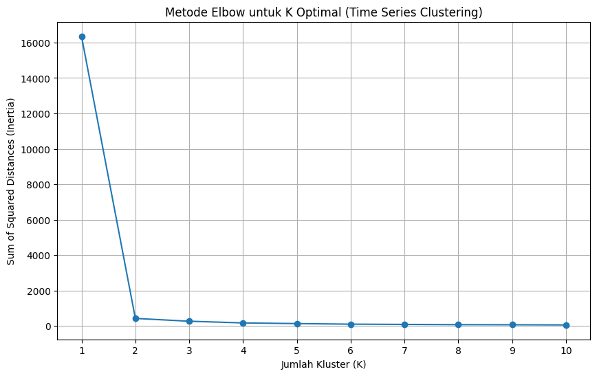

```
Plot Metode Elbow telah dibuat.
```

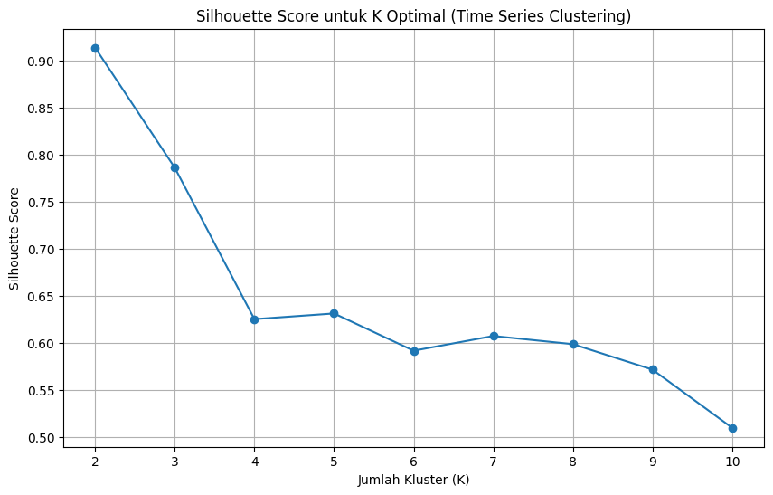

```
Plot Silhouette Score telah dibuat.

--- Interpretasi ---
Untuk Metode Elbow, cari titik 'siku' pada grafik di mana laju penurunan SSD berubah secara tajam.
Untuk Silhouette Score, K optimal biasanya adalah yang menghasilkan skor tertinggi.
```

```python
from sklearn.cluster import KMeans
from sklearn.metrics import silhouette_score
import matplotlib.pyplot as plt
import seaborn as sns
import numpy as np

print("### Menentukan K Optimal untuk Time Series Clustering ###\n")

# Memastikan X_scaled_ts_clustering tersedia dari langkah sebelumnya
# X_scaled_ts_clustering sudah dihitung dari df_pivot_ts_clustering

# Handle NaN values in X_scaled_ts_clustering before KMeans
X_scaled_ts_clustering = np.nan_to_num(X_scaled_ts_clustering, nan=0.0)

# --- Metode Elbow ---
ssd = [] # Sum of squared distances
K_range = range(1, 11) # Menguji K dari 1 hingga 10

for k in K_range:
    # Pastikan n_init diatur untuk KMeans agar tidak ada peringatan
    kmeans_model = KMeans(n_clusters=k, random_state=42, n_init=10)
    kmeans_model.fit(X_scaled_ts_clustering)
    ssd.append(kmeans_model.inertia_)

plt.figure(figsize=(10, 6))
plt.plot(K_range, ssd, marker='o')
plt.title('Metode Elbow untuk K Optimal (Time Series Clustering)')
plt.xlabel('Jumlah Kluster (K)')
plt.ylabel('Sum of Squared Distances (Inertia)')
plt.xticks(K_range)
plt.grid(True)
plt.show()

print("\nPlot Metode Elbow telah dibuat.")

# --- Metode Silhouette Score ---
silhouette_scores = []
K_range_silhouette = range(2, 11) # Silhouette score memerlukan minimal 2 kluster

for k in K_range_silhouette:
    # Pastikan n_init diatur untuk KMeans agar tidak ada peringatan
    kmeans_model = KMeans(n_clusters=k, random_state=42, n_init=10)
    cluster_labels = kmeans_model.fit_predict(X_scaled_ts_clustering)
    silhouette_avg = silhouette_score(X_scaled_ts_clustering, cluster_labels)
    silhouette_scores.append(silhouette_avg)

plt.figure(figsize=(10, 6))
plt.plot(K_range_silhouette, silhouette_scores, marker='o')
plt.title('Silhouette Score untuk K Optimal (Time Series Clustering)')
plt.xlabel('Jumlah Kluster (K)')
plt.ylabel('Silhouette Score')
plt.xticks(K_range_silhouette)
plt.grid(True)
plt.show()

print("\nPlot Silhouette Score telah dibuat.")
print("\n--- Interpretasi ---\nUntuk Metode Elbow, cari titik 'siku' pada grafik di mana laju penurunan SSD berubah secara tajam. \nUntuk Silhouette Score, K optimal biasanya adalah yang menghasilkan skor tertinggi.")
```

# K-Means Clustering

```
### Clustering Berdasarkan Tingkat Harga (Magnitude/Severity) ###

Data agregasi rata-rata harga per produk (pertama 5 baris):
```

|  | KabKot | Mean_Harga_Ayam | Mean_Harga_Sapi | Mean_Harga_Telur |
| --- | --- | --- | --- | --- |
| 0 | Kab. Bandung | 35277.630435 | 133922.913043 | 27665.391304 |
| 1 | Kab. Bandung Barat | 34136.630435 | 126191.391304 | 27724.369565 |
| 2 | Kab. Bangkalan | 36872.739130 | 118591.021739 | 26979.565217 |
| 3 | Kab. Banjarnegara | 32337.108696 | 132590.543478 | 27163.782609 |
| 4 | Kab. Bantul | 33436.804348 | 131902.086957 | 26942.956522 |

```
K-Means Clustering dengan K=2 kluster telah dilakukan.
Distribusi Kluster:
Magnitude_Cluster
0    72
1    47
Name: count, dtype: int64
Silhouette Score untuk Clustering Magnitude (K=2): 0.3811
```

[figure not shown]

[figure not shown]

[output not shown]

```python
from sklearn.preprocessing import StandardScaler
from sklearn.cluster import KMeans
import matplotlib.pyplot as plt
import seaborn as sns
import pandas as pd
from sklearn.metrics import silhouette_score # Import silhouette_score

print("### Clustering Berdasarkan Tingkat Harga (Magnitude/Severity) ###\n")

# 1. Agregasi Data: Hitung rata-rata harga per KabKot untuk setiap Produk
# Gunakan df_result yang sudah berisi hasil interpolasi dan pemfilteran untuk Jawa.
mean_prices_per_product = df_result.groupby(['KabKot', 'Produk'])['Harga'].mean().reset_index()

# 2. Pivot Data: Ubah bentuk data agar setiap KabKot menjadi baris, dan rata-rata harga produk menjadi kolom
# Ini akan membuat kolom-kolom seperti 'Daging Ayam Ras', 'Daging Sapi Murni', 'Telur Ayam Ras'
clustering_data_magnitude = mean_prices_per_product.pivot(index='KabKot', columns='Produk', values='Harga')
clustering_data_magnitude.columns.name = None # Remove columns name
clustering_data_magnitude.reset_index(inplace=True)

# Rename columns for clarity
clustering_data_magnitude.rename(columns={
    'Daging Ayam Ras': 'Mean_Harga_Ayam',
    'Daging Sapi Murni': 'Mean_Harga_Sapi',
    'Telur Ayam Ras': 'Mean_Harga_Telur'
}, inplace=True)

# Handle any potential NaNs that might arise if a KabKot doesn't have data for a specific product
clustering_data_magnitude.fillna(0, inplace=True)

print("Data agregasi rata-rata harga per produk (pertama 5 baris):")
display(clustering_data_magnitude.head())

# 3. Fitur Input: Rata_rata_Harga_Ayam, Rata_rata_Harga_Sapi, Rata_rata_Harga_Telur
X_magnitude = clustering_data_magnitude[['Mean_Harga_Ayam', 'Mean_Harga_Sapi', 'Mean_Harga_Telur']]

# 4. Scaling Fitur
scaler_magnitude = StandardScaler()
X_scaled_magnitude = scaler_magnitude.fit_transform(X_magnitude)

# 5. K-Means Clustering dengan k=2
k_magnitude = 2
kmeans_magnitude = KMeans(n_clusters=k_magnitude, random_state=42, n_init=10)
clustering_data_magnitude['Magnitude_Cluster'] = kmeans_magnitude.fit_predict(X_scaled_magnitude)

print(f"\nK-Means Clustering dengan K={k_magnitude} kluster telah dilakukan.")
print("Distribusi Kluster:")
print(clustering_data_magnitude['Magnitude_Cluster'].value_counts())

# Calculate Silhouette Score for Magnitude Clustering
silhouette_avg_magnitude = silhouette_score(X_scaled_magnitude, clustering_data_magnitude['Magnitude_Cluster'])
print(f"Silhouette Score untuk Clustering Magnitude (K={k_magnitude}): {silhouette_avg_magnitude:.4f}")

# 6. Visualisasi Hasil Clustering
# Untuk visualisasi 2D, kita bisa memilih dua fitur utama atau menggunakan PairPlot
plt.figure(figsize=(10, 7))
sns.scatterplot(x='Mean_Harga_Ayam', y='Mean_Harga_Sapi', hue='Magnitude_Cluster', data=clustering_data_magnitude,
                palette='viridis', s=100, alpha=0.8)
plt.title(f'K-Means Clustering (K={k_magnitude}) Berdasarkan Rata-rata Harga Produk')
plt.xlabel('Rata-rata Harga Daging Ayam Ras (Scaled)')
plt.ylabel('Rata-rata Harga Daging Sapi Murni (Scaled)')
plt.grid(True)
plt.legend(title='Cluster')
plt.show()

plt.figure(figsize=(10, 7))
sns.scatterplot(x='Mean_Harga_Ayam', y='Mean_Harga_Telur', hue='Magnitude_Cluster', data=clustering_data_magnitude,
                palette='viridis', s=100, alpha=0.8)
plt.title(f'K-Means Clustering (K={k_magnitude}) Berdasarkan Rata-rata Harga Produk')
plt.xlabel('Rata-rata Harga Daging Ayam Ras (Scaled)')
plt.ylabel('Rata-rata Harga Telur Ayam Ras (Scaled)')
plt.grid(True)
plt.legend(title='Cluster')
plt.show()

# Jika ingin visualisasi 3D (opsional dan lebih kompleks)
# from mpl_toolkits.mplot3d import Axes3D
# fig = plt.figure(figsize=(12, 10))
# ax = fig.add_subplot(111, projection='3d')
# scatter = ax.scatter(clustering_data_magnitude['Mean_Harga_Ayam'],
#                      clustering_data_magnitude['Mean_Harga_Sapi'],
#                      c=clustering_data_magnitude['Magnitude_Cluster'], cmap='viridis', s=100)
# ax.set_xlabel('Mean Harga Ayam')
# ax.set_ylabel('Mean Harga Sapi')
# ax.set_zlabel('Mean Harga Telur')
# plt.title(f'K-Means Clustering (K={k_magnitude}) 3D Plot')
# plt.colorbar(scatter, label='Cluster')
# plt.show()

print("\n--- Interpretasi Hasil Klustering ---\n")
# Untuk interpretasi, kita bisa melihat rata-rata fitur di setiap kluster
cluster_summary = clustering_data_magnitude.groupby('Magnitude_Cluster')[['Mean_Harga_Ayam', 'Mean_Harga_Sapi', 'Mean_Harga_Telur']].mean()
print("Rata-rata harga per kluster (sebelum scaling, untuk interpretasi):\n")
print(cluster_summary)

print("\nDistribusi KabKot per Kluster:\n")
for cluster_id in sorted(clustering_data_magnitude['Magnitude_Cluster'].unique()):
    print(f"Kluster {cluster_id}:")
    kabkots_in_cluster = clustering_data_magnitude[clustering_data_magnitude['Magnitude_Cluster'] == cluster_id]['KabKot'].tolist()
    print(kabkots_in_cluster)
    print("\n")
```

## K-Means Time Series Clustering per Product (K=2, K=3)

### Subtask:

Iterate through each unique protein product ('Daging Ayam Ras', 'Daging Sapi Murni', 'Telur Ayam Ras'). For each product, pivot the `df_result` DataFrame to create time series data where rows are 'KabKot' and columns are 'tanggal'. Handle any remaining NaNs, then scale these time series features. Apply K-Means clustering with `k=2` and `k=3` clusters. For each clustering, visualize representative time series from each cluster with appropriate labels and legends. Display the cluster distribution for each product and K value.

```python
import pandas as pd
from sklearn.preprocessing import StandardScaler
from sklearn.cluster import KMeans
import matplotlib.pyplot as plt
import seaborn as sns
import numpy as np

print("### K-Means Time Series Clustering per Product (K=2, K=3) ###\n")

# 1. Define a list of unique protein products
protein_products = ['Daging Ayam Ras', 'Daging Sapi Murni', 'Telur Ayam Ras']
k_values = [2, 3]

for product in protein_products:
    print(f"\n--- Processing Product: {product} ---")

    # 2.a. Filter df_result for the current product
    df_product = df_result[df_result['Produk'] == product].copy()

    # 2.b. Pivot the filtered DataFrame
    # Ensure 'tanggal' is sorted before pivoting
    df_product.sort_values(by='tanggal', inplace=True)
    df_product_pivot = df_product.pivot_table(index='KabKot', columns='tanggal', values='Harga')

    # 2.c. Handle any remaining NaN values in df_product_pivot
    df_product_pivot.ffill(axis=1, inplace=True)
    df_product_pivot.bfill(axis=1, inplace=True)
    if df_product_pivot.isnull().values.any():
        print(f"Warning: NaNs still present in {product} after ffill/bfill. Filling with 0.")
        df_product_pivot.fillna(0, inplace=True)

    # 2.d. Extract the values and 2.e. Scale the time series features
    if not df_product_pivot.empty:
        X_ts_product = df_product_pivot.values
        scaler_ts_product = StandardScaler()
        X_scaled_ts_product = scaler_ts_product.fit_transform(X_ts_product)

        # 2.f. Iterate through k values for clustering
        for k in k_values:
            print(f"\nApplying K-Means with K={k} for {product}...")
            # 2.g.i. Initialize KMeans
            kmeans_ts_product = KMeans(n_clusters=k, random_state=42, n_init=10) # n_init to suppress warning

            # 2.g.ii. Fit and predict cluster labels
            cluster_labels = kmeans_ts_product.fit_predict(X_scaled_ts_product)
            df_product_pivot[f'Cluster_{k}'] = cluster_labels

            # 2.g.iii. Display cluster distribution
            print(f"Cluster distribution for {product} (K={k}):")
            print(df_product_pivot[f'Cluster_{k}'].value_counts())

            # 2.g.iv. Visualize representative time series from each cluster
            print(f"Visualizing representative time series for {product} (K={k})...")
            fig, axes = plt.subplots(k, 1, figsize=(15, 6 * k), sharex=True)
            if k == 1: # Ensure axes is always an array for consistent indexing
                axes = [axes]
            fig.suptitle(f'K-Means Clustering: {product} (K={k}) - Representative Time Series', fontsize=16)

            # Get only the datetime columns for plotting
            date_cols_for_plot = [col for col in df_product_pivot.columns if isinstance(col, pd.Timestamp)]

            for cluster_id in range(k):
                ax = axes[cluster_id]
                # Get KabKots in the current cluster
                kabkots_in_cluster = df_product_pivot[df_product_pivot[f'Cluster_{k}'] == cluster_id].index.tolist()

                # Select up to 5 KabKots for visualization
                num_series_to_plot = min(len(kabkots_in_cluster), 5)
                # Handle case where there are no kabkots in the cluster
                if num_series_to_plot > 0:
                    selected_kabkots = np.random.choice(kabkots_in_cluster, num_series_to_plot, replace=False)
                else:
                    selected_kabkots = []

                if not selected_kabkots.tolist(): # Check if list is empty
                    ax.text(0.5, 0.5, 'No KabKots in this cluster to display.', horizontalalignment='center', verticalalignment='center', transform=ax.transAxes)
                    ax.set_title(f'Cluster {cluster_id} (No Data)')
                    continue

                for kabkot in selected_kabkots:
                    # Plot original (unscaled) Harga time series, using only date columns
                    series_data = df_product_pivot.loc[kabkot, date_cols_for_plot]
                    sns.lineplot(x=series_data.index, y=series_data.values, ax=ax, label=kabkot)

                ax.set_title(f'Cluster {cluster_id}')
                ax.set_xlabel('Tanggal')
                ax.set_ylabel('Harga')
                ax.legend(title='KabKot')
                ax.grid(True)
            plt.tight_layout(rect=[0, 0.03, 1, 0.95])
            plt.show()
    else:
        print(f"No data available for product: {product}. Skipping clustering.")

print("\n### All K-Means Time Series Clusterings completed. ###")
```

[output not shown]

[output not shown]

## Evaluasi K-Means Clustering dengan Silhouette Score

### Subtask:

Menghitung dan menampilkan *Silhouette Score* untuk hasil *K-Means clustering* pada data deret waktu dengan `K=2` dan `K=3`.

```python
from sklearn.metrics import silhouette_score
import numpy as np
from sklearn.cluster import KMeans # Import KMeans

print("### Evaluasi K-Means Clustering dengan Silhouette Score ###\n")

# Perform K-Means for K=2 on the overall scaled time series data
k_val_2 = 2
kmeans_model_k2 = KMeans(n_clusters=k_val_2, random_state=42, n_init=10)
df_pivot_ts_clustering['Cluster_K2'] = kmeans_model_k2.fit_predict(X_scaled_ts_clustering)

# Perform K-Means for K=3 on the overall scaled time series data
k_val_3 = 3
kmeans_model_k3 = KMeans(n_clusters=k_val_3, random_state=42, n_init=10)
df_pivot_ts_clustering['Cluster_K3'] = kmeans_model_k3.fit_predict(X_scaled_ts_clustering)


# --- Evaluasi untuk K=2 ---
if 'Cluster_K2' in df_pivot_ts_clustering.columns:
    silhouette_avg_k2 = silhouette_score(X_scaled_ts_clustering, df_pivot_ts_clustering['Cluster_K2'])
    print(f"Silhouette Score untuk K-Means (K={k_val_2}): {silhouette_avg_k2:.4f}")
else:
    print(f"Error: Hasil K-Means untuk K={k_val_2} tidak ditemukan. Ini seharusnya tidak terjadi.")

# --- Evaluasi untuk K=3 ---
if 'Cluster_K3' in df_pivot_ts_clustering.columns:
    silhouette_avg_k3 = silhouette_score(X_scaled_ts_clustering, df_pivot_ts_clustering['Cluster_K3'])
    print(f"Silhouette Score untuk K-Means (K={k_val_3}): {silhouette_avg_k3:.4f}")
else:
    print(f"Error: Hasil K-Means untuk K={k_val_3} tidak ditemukan. Ini seharusnya tidak terjadi.")

print("\n--- Interpretasi Silhouette Score ---")
print("Mendekati 1 berarti kluster terpisah dengan baik dan padat.")
print("Mendekati 0 berarti kluster tumpang tindih.")
print("Negatif berarti data salah dikelompokkan.")
```

```
### Evaluasi K-Means Clustering dengan Silhouette Score ###

Silhouette Score untuk K-Means (K=2): 0.9139
Silhouette Score untuk K-Means (K=3): 0.7863

--- Interpretasi Silhouette Score ---
Mendekati 1 berarti kluster terpisah dengan baik dan padat.
Mendekati 0 berarti kluster tumpang tindih.
Negatif berarti data salah dikelompokkan.
```

## Clustering Berdasarkan Stabilitas/Volatilitas (Risk Profile) dengan Fuzzy C-Means

### Subtask:

Mengelompokkan daerah berdasarkan stabilitas atau volatilitas harga menggunakan algoritma Fuzzy C-Means (FCM). Fitur input meliputi Koefisien Variasi (CV), Max Drawdown, dan Standard Deviation. Interpretasikan kluster yang dihasilkan.

**Reasoning**: Untuk mengelompokkan daerah berdasarkan stabilitas/volatilitas harga menggunakan FCM, saya akan melakukan langkah-langkah berikut:

1. **Hitung Fitur Volatilitas**: Untuk setiap kombinasi `KabKot` dan `Produk`, hitung `Mean_Harga`, `Std_Harga`, `Koefisien Variasi (CV)`, dan `Max Drawdown` dari deret waktu harga.
   - `CV = Std_Harga / Mean_Harga`
   - `Max Drawdown`: Penurunan harga terbesar dari puncak ke lembah berikutnya.
2. **Gabungkan Fitur**: Susun fitur-fitur ini ke dalam satu DataFrame.
3. **Scaling Fitur**: Skalakan fitur-fitur volatilitas menggunakan `StandardScaler` untuk memastikan kontribusi yang setara dalam algoritma *clustering*.
4. **Terapkan FCM**: Gunakan algoritma *Fuzzy C-Means* (dari `scikit-fuzzy`) pada data yang telah diskalakan. Kita akan menggunakan `k=2` kluster sesuai interpretasi 'Stabil' dan 'Volatil'.
5. **Visualisasi dan Interpretasi**: Visualisasikan hasil *clustering* menggunakan *scatter plot* dari dua fitur utama (misalnya CV vs Std Dev) dan warnai berdasarkan kluster FCM. Lalu, interpretasikan karakteristik setiap kluster berdasarkan nilai rata-rata fiturnya untuk mengidentifikasi profil risiko ('Stabil' atau 'Volatil').

```
### Clustering Berdasarkan Stabilitas/Volatilitas (Risk Profile) ###
```

```
/tmp/ipython-input-426410942.py:46: FutureWarning: DataFrame.fillna with 'method' is deprecated and will raise in a future version. Use obj.ffill() or obj.bfill() instead.
  df_time_series_pivot = df_time_series_pivot.fillna(method='ffill').fillna(method='bfill').fillna(0) # Ensure no NaNs
```

```
Data agregasi fitur risiko per produk (pertama 5 baris):
```

|  | KabKot | Produk | Mean_Harga | Std_Harga | CV | Max_Drawdown |
| --- | --- | --- | --- | --- | --- | --- |
| 0 | Kab. Bandung | Daging Ayam Ras | 35277.630435 | 2201.594264 | 0.062408 | 0.202979 |
| 1 | Kab. Bandung | Daging Sapi Murni | 133922.913043 | 5854.258415 | 0.043714 | 0.133454 |
| 2 | Kab. Bandung | Telur Ayam Ras | 27665.391304 | 2122.202069 | 0.076710 | 0.221884 |
| 3 | Kab. Bandung Barat | Daging Ayam Ras | 34136.630435 | 2259.784703 | 0.066198 | 0.233286 |
| 4 | Kab. Bandung Barat | Daging Sapi Murni | 126191.391304 | 4205.800463 | 0.033329 | 0.128246 |

```
Fuzzy C-Means Clustering dengan K=2 kluster telah dilakukan.
Distribusi Kluster:
Risk_Cluster
0    235
1    122
Name: count, dtype: int64
```

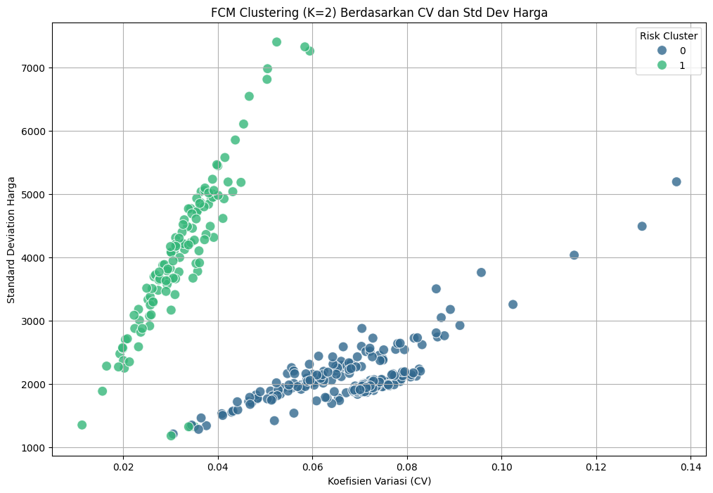

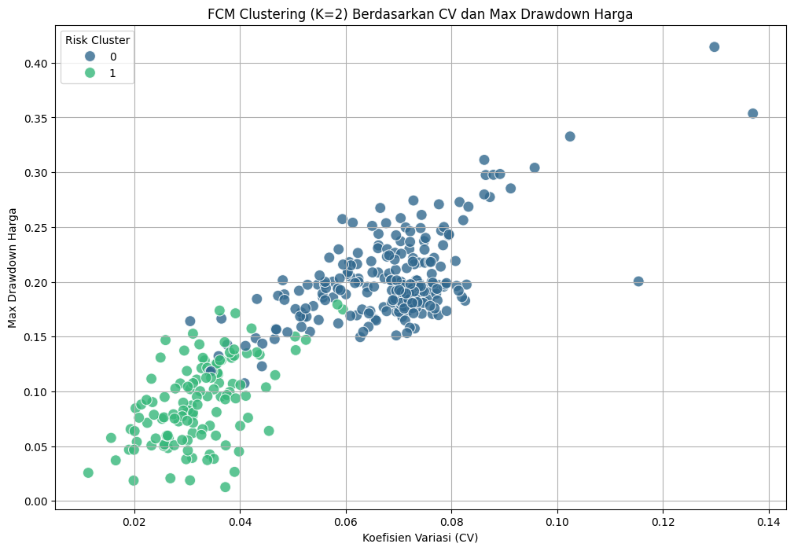

```
--- Interpretasi Hasil Klustering ---

Rata-rata fitur risiko per kluster (sebelum scaling, untuk interpretasi):

                    CV  Max_Drawdown    Std_Harga
Risk_Cluster
0             0.068260      0.200571  2102.011296
1             0.032334      0.090669  4058.138229

Distribusi KabKot-Produk per Kluster Risiko:

Kluster 0:
  - Kab. Bandung - Daging Ayam Ras
  - Kab. Bandung - Telur Ayam Ras
  - Kab. Bandung Barat - Daging Ayam Ras
  - Kab. Bandung Barat - Telur Ayam Ras
  - Kab. Bangkalan - Daging Ayam Ras
  - Kab. Bangkalan - Telur Ayam Ras
  - Kab. Banjarnegara - Daging Ayam Ras
  - Kab. Banjarnegara - Telur Ayam Ras
  - Kab. Bantul - Daging Ayam Ras
  - Kab. Bantul - Telur Ayam Ras
  - Kab. Banyumas - Daging Ayam Ras
  - Kab. Banyumas - Telur Ayam Ras
  - Kab. Banyuwangi - Daging Ayam Ras
  - Kab. Banyuwangi - Telur Ayam Ras
  - Kab. Batang - Daging Ayam Ras
  - Kab. Batang - Telur Ayam Ras
  - Kab. Bekasi - Daging Ayam Ras
  - Kab. Bekasi - Telur Ayam Ras
  - Kab. Blitar - Daging Ayam Ras
  - Kab. Blitar - Telur Ayam Ras
  - Kab. Blora - Daging Ayam Ras
  - Kab. Blora - Telur Ayam Ras
  - Kab. Bogor - Daging Ayam Ras
  - Kab. Bogor - Telur Ayam Ras
  - Kab. Bojonegoro - Daging Ayam Ras
  - Kab. Bojonegoro - Telur Ayam Ras
  - Kab. Bondowoso - Daging Ayam Ras
  - Kab. Bondowoso - Telur Ayam Ras
```

[output cut: 317 more lines]

```
  - Kota Pasuruan - Daging Sapi Murni
  - Kota Pekalongan - Daging Sapi Murni
  - Kota Probolinggo - Daging Sapi Murni
  - Kota Salatiga - Daging Sapi Murni
  - Kota Semarang - Daging Sapi Murni
  - Kota Serang - Daging Sapi Murni
  - Kota Sukabumi - Daging Sapi Murni
  - Kota Surabaya - Daging Sapi Murni
  - Kota Surakarta - Daging Sapi Murni
  - Kota Tangerang - Daging Sapi Murni
  - Kota Tangerang Selatan - Daging Ayam Ras
  - Kota Tangerang Selatan - Daging Sapi Murni
  - Kota Tasikmalaya - Daging Sapi Murni
  - Kota Tegal - Daging Sapi Murni
  - Kota Yogyakarta - Daging Sapi Murni
```

```python
try:
    import skfuzzy as fuzz
    from skfuzzy import cmeans
except ImportError:
    print("Installing 'scikit-fuzzy' library...")
    !pip install scikit-fuzzy
    import skfuzzy as fuzz
    from skfuzzy import cmeans

from sklearn.preprocessing import StandardScaler
import matplotlib.pyplot as plt
import seaborn as sns
import numpy as np
import pandas as pd

print("### Clustering Berdasarkan Stabilitas/Volatilitas (Risk Profile) ###\n")

# Function to calculate Max Drawdown for a time series (assuming input is a Series of prices)
def calculate_max_drawdown(series):
    if series.empty or series.isnull().all():
        return 0.0 # Return 0 if no valid data to avoid NaN issues in clustering

    series = series.dropna()
    if series.empty:
        return 0.0

    # Handle non-positive prices to avoid issues in percentage calculations for drawdown
    # Max drawdown is typically calculated for positive values like stock prices
    if (series <= 0).any():
        return 0.0 # Or np.nan, depending on desired handling of invalid price series

    # Calculate rolling maximum
    rolling_max = series.cummax()

    # Calculate drawdown
    drawdown = (series - rolling_max) / rolling_max

    # Max drawdown is the minimum value of the drawdown series
    max_drawdown = drawdown.min()
    return abs(max_drawdown) # Expressed as a positive value

# 1. Hitung Fitur Volatilitas
# Pivot df_result to get time series for each KabKot-Produk
# This is needed for Max Drawdown calculation
df_time_series_pivot = df_result.pivot_table(index='tanggal', columns=['KabKot', 'Produk'], values='Harga')
df_time_series_pivot = df_time_series_pivot.fillna(method='ffill').fillna(method='bfill').fillna(0) # Ensure no NaNs

# Prepare features DataFrame
clustering_data_risk = df_result.groupby(['KabKot', 'Produk'])['Harga'].agg(Mean_Harga='mean', Std_Harga='std').reset_index()

# Calculate CV
clustering_data_risk['CV'] = clustering_data_risk['Std_Harga'] / clustering_data_risk['Mean_Harga']

# Calculate Max Drawdown for each KabKot-Produk time series
max_drawdown_list = []
for index_tuple, _ in df_time_series_pivot.T.iterrows():
    kabkot, produk = index_tuple
    series_for_drawdown = df_time_series_pivot[(kabkot, produk)]
    max_drawdown_list.append(calculate_max_drawdown(series_for_drawdown))

# Create a DataFrame for Max Drawdown results and merge it
df_max_drawdown = pd.DataFrame({'KabKot': [idx[0] for idx in df_time_series_pivot.columns],
                                'Produk': [idx[1] for idx in df_time_series_pivot.columns],
                                'Max_Drawdown': max_drawdown_list})
clustering_data_risk = pd.merge(clustering_data_risk, df_max_drawdown, on=['KabKot', 'Produk'], how='left')

# Handle potential NaNs from feature calculation (e.g., Std_Harga=0, Mean_Harga=0 leading to NaN CV)
clustering_data_risk.fillna(0, inplace=True) # Fill NaNs with 0 for safety

print("Data agregasi fitur risiko per produk (pertama 5 baris):")
display(clustering_data_risk.head())

# 2. Fitur Input: CV, Max_Drawdown, Standard_Deviation
X_risk = clustering_data_risk[['CV', 'Max_Drawdown', 'Std_Harga']]

# 3. Scaling Fitur
scaler_risk = StandardScaler()
X_scaled_risk = scaler_risk.fit_transform(X_risk)

# Transpose X_scaled_risk for skfuzzy.cmeans
X_scaled_risk_T = X_scaled_risk.T

# 4. Terapkan FCM Clustering dengan k=2
k_risk = 2

# Apply Fuzzy C-Means clustering using skfuzzy
cntr, u, u0, d, jm, p, fpc = cmeans(
    X_scaled_risk_T,
    k_risk,
    2,  # Fuzziness parameter (m)
    error=0.005,
    maxiter=1000,
    init=None
)

# Get cluster assignments (hard assignment based on max membership)
clustering_data_risk['Risk_Cluster'] = np.argmax(u, axis=0)

print(f"\nFuzzy C-Means Clustering dengan K={k_risk} kluster telah dilakukan.")
print("Distribusi Kluster:")
print(clustering_data_risk['Risk_Cluster'].value_counts())

# 5. Visualisasi Hasil Clustering
plt.figure(figsize=(12, 8))
sns.scatterplot(x='CV', y='Std_Harga', hue='Risk_Cluster', data=clustering_data_risk,
                palette='viridis', s=100, alpha=0.8)
plt.title(f'FCM Clustering (K={k_risk}) Berdasarkan CV dan Std Dev Harga')
plt.xlabel('Koefisien Variasi (CV)')
plt.ylabel('Standard Deviation Harga')
plt.grid(True)
plt.legend(title='Risk Cluster')
plt.show()

plt.figure(figsize=(12, 8))
sns.scatterplot(x='CV', y='Max_Drawdown', hue='Risk_Cluster', data=clustering_data_risk,
                palette='viridis', s=100, alpha=0.8)
plt.title(f'FCM Clustering (K={k_risk}) Berdasarkan CV dan Max Drawdown Harga')
plt.xlabel('Koefisien Variasi (CV)')
plt.ylabel('Max Drawdown Harga')
plt.grid(True)
plt.legend(title='Risk Cluster')
plt.show()

print("\n--- Interpretasi Hasil Klustering ---\n")
# Untuk interpretasi, kita bisa melihat rata-rata fitur di setiap kluster
cluster_summary_risk = clustering_data_risk.groupby('Risk_Cluster')[['CV', 'Max_Drawdown', 'Std_Harga']].mean()
print("Rata-rata fitur risiko per kluster (sebelum scaling, untuk interpretasi):\n")
print(cluster_summary_risk)

print("\nDistribusi KabKot-Produk per Kluster Risiko:\n")
for cluster_id in sorted(clustering_data_risk['Risk_Cluster'].unique()):
    print(f"Kluster {cluster_id}:")
    kabkot_produk_in_cluster = clustering_data_risk[clustering_data_risk['Risk_Cluster'] == cluster_id][['KabKot', 'Produk']].values.tolist()
    for item in kabkot_produk_in_cluster:
        print(f"  - {item[0]} - {item[1]}")
    print("\n")
```

## Analisis Validitas FCM (Fuzzy Partition Coefficient - FPC)

### Subtask:

Menampilkan dan menginterpretasikan nilai *Fuzzy Partition Coefficient (FPC)* dari hasil *FCM clustering* yang telah dilakukan sebelumnya untuk analisis stabilitas/volatilitas.

**Reasoning**: *Fuzzy Partition Coefficient (FPC)* adalah metrik umum untuk mengevaluasi kualitas *fuzzy clustering*. Nilai FPC berkisar dari $1/k$ (partisi paling kabur, di mana $k$ adalah jumlah kluster) hingga 1 (partisi paling jelas). Nilai FPC yang lebih tinggi menunjukkan bahwa kluster lebih terpisah dan data lebih cenderung termasuk dalam satu kluster daripada yang lain. Karena nilai `fpc` sudah dihitung oleh fungsi `skfuzzy.cmeans` sebelumnya, kita hanya perlu menampilkannya dan memberikan interpretasi.

```python
import numpy as np
import pandas as pd # Import pandas for displaying df_result info
from sklearn.metrics import silhouette_score # Import for Silhouette Score

print("### Analisis Validitas FCM (Fuzzy Partition Coefficient, Partition Entropy, Silhouette Score) ###\n")

# fpc, u, X_scaled_risk, clustering_data_risk['Risk_Cluster'] sudah dihitung di cell sebelumnya.
# Pastikan variabel-variabel tersebut tersedia. Jika tidak, jalankan kembali cell FCM clustering.

if 'fpc' in locals() and 'u' in locals() and 'X_scaled_risk' in locals() and 'clustering_data_risk' in locals():
    k_risk = 2 # Jumlah kluster yang digunakan untuk FCM volatilitas

    # Hitung Partition Entropy (PE)
    # PE = - sum_i=1^N sum_j=1^k (u_ij * log_b(u_ij))
    # u is the fuzzy partition matrix
    pe = -np.sum(u * np.log2(u + 1e-9)) / X_scaled_risk.shape[0] # Add small epsilon to avoid log(0)

    # Hitung Silhouette Score (berdasarkan hard assignment)
    silhouette_avg_fcm = silhouette_score(X_scaled_risk, clustering_data_risk['Risk_Cluster'])

    print(f"Nilai Fuzzy Partition Coefficient (FPC): {fpc:.4f}")
    print(f"Nilai Partition Entropy (PE): {pe:.4f}")
    print(f"Nilai Silhouette Score (berdasarkan hard assignment): {silhouette_avg_fcm:.4f}")
    print(f"Interpretasi FPC:\n")
    print(f"Nilai FPC berada di antara 1/{k_risk} = {1/k_risk:.4f} (paling kabur) dan 1 (paling jelas).\n")

    if fpc > (1/k_risk) and fpc < 0.5: # Biasanya FPC < 0.5 dianggap sangat kabur untuk 2 kluster
        print("FPC ini menunjukkan partisi kluster yang cukup kabur. Ada tingkat tumpang tindih yang tinggi antara kluster, atau data tidak memiliki struktur kluster yang sangat jelas berdasarkan fitur volatilitas yang digunakan.")
    elif fpc >= 0.5 and fpc < 0.7:
        print("FPC ini menunjukkan partisi kluster yang cukup moderat. Ada pemisahan yang wajar antara kluster, tetapi masih ada beberapa tumpang tindih.")
    elif fpc >= 0.7:
        print("FPC ini menunjukkan partisi kluster yang relatif jelas. Kluster cukup terpisah satu sama lain berdasarkan fitur volatilitas.")
    else:
        print("Nilai FPC menunjukkan partisi yang sangat kabur, mendekati batas bawah 1/k.")

    print("\nUntuk Klustering Stabilitas/Volatilitas, nilai FPC yang lebih tinggi umumnya diinginkan, menunjukkan bahwa kluster 'Stabil' dan 'Volatil' memiliki karakteristik yang lebih berbeda satu sama lain.")

    print("\n--- Interpretasi PE dan Silhouette Score ---")
    print("PE (Partition Entropy): Mendekati 0 berarti partisi lebih jelas (baik). Nilai yang lebih tinggi menunjukkan partisi yang lebih kabur.")
    print("Silhouette Score: Mendekati 1 berarti kluster terpisah dengan baik dan padat. Mendekati 0 berarti kluster tumpang tindih. Negatif berarti data salah dikelompokkan.")

else:
    print("Error: Variabel yang diperlukan (fpc, u, X_scaled_risk, clustering_data_risk) tidak ditemukan. Pastikan cell FCM Clustering telah dijalankan sebelumnya.")
```

```
### Analisis Validitas FCM (Fuzzy Partition Coefficient, Partition Entropy, Silhouette Score) ###

Nilai Fuzzy Partition Coefficient (FPC): 0.8685
Nilai Partition Entropy (PE): 0.3360
Nilai Silhouette Score (berdasarkan hard assignment): 0.6281
Interpretasi FPC:

Nilai FPC berada di antara 1/2 = 0.5000 (paling kabur) dan 1 (paling jelas).

FPC ini menunjukkan partisi kluster yang relatif jelas. Kluster cukup terpisah satu sama lain berdasarkan fitur volatilitas.

Untuk Klustering Stabilitas/Volatilitas, nilai FPC yang lebih tinggi umumnya diinginkan, menunjukkan bahwa kluster 'Stabil' dan 'Volatil' memiliki karakteristik yang lebih berbeda satu sama lain.

--- Interpretasi PE dan Silhouette Score ---
PE (Partition Entropy): Mendekati 0 berarti partisi lebih jelas (baik). Nilai yang lebih tinggi menunjukkan partisi yang lebih kabur.
Silhouette Score: Mendekati 1 berarti kluster terpisah dengan baik dan padat. Mendekati 0 berarti kluster tumpang tindih. Negatif berarti data salah dikelompokkan.
```

# Extract Cluster Representatives for Granger Causality

```python
import pandas as pd
from sklearn.preprocessing import StandardScaler
from sklearn.cluster import KMeans
import numpy as np

print("### Extracting Cluster Centroids for Granger Causality Analysis (K=2) ###\n")

# protein_products and df_result are available from previous steps
protein_products = ['Daging Ayam Ras', 'Daging Sapi Murni', 'Telur Ayam Ras']

# 1. Initialize an empty dictionary to store pivoted DataFrames with K=2 cluster assignments
product_pivot_dfs_k2 = {}

# 2. Iterate through each protein_product
for product in protein_products:
    print(f"Processing {product} for K-Means (K=2) and centroid extraction...")

    # a. Filter df_result for the current product
    df_product = df_result[df_result['Produk'] == product].copy()

    # b. Sort the filtered data by 'tanggal' and then pivot it
    df_product.sort_values(by='tanggal', inplace=True)
    df_product_pivot = df_product.pivot_table(index='KabKot', columns='tanggal', values='Harga')

    # c. Handle any remaining NaN values in df_product_pivot
    df_product_pivot.ffill(axis=1, inplace=True) # Forward fill row-wise
    df_product_pivot.bfill(axis=1, inplace=True) # Backward fill row-wise
    if df_product_pivot.isnull().values.any():
        print(f"Warning: NaNs still present in pivoted data for {product}. Filling with 0.")
        df_product_pivot.fillna(0, inplace=True)

    # d. Extract the numerical values and scale them
    if not df_product_pivot.empty:
        X_ts_product = df_product_pivot.values
        scaler_ts_product = StandardScaler()
        X_scaled_ts_product = scaler_ts_product.fit_transform(X_ts_product)

        # e. Apply K-Means clustering with n_clusters=2
        kmeans_model = KMeans(n_clusters=2, random_state=42, n_init=10)
        cluster_labels = kmeans_model.fit_predict(X_scaled_ts_product)
        df_product_pivot['Cluster_2'] = cluster_labels

        # f. Store this modified df_product_pivot
        product_pivot_dfs_k2[product] = df_product_pivot
        print(f"Stored pivoted data with K=2 clusters for {product}. Cluster distribution:\n{df_product_pivot['Cluster_2'].value_counts()}\n")
    else:
        print(f"No pivoted data generated for {product}. Skipping clustering and centroid extraction.")

# 3. Initialize another empty dictionary for centroids
cluster_centroids_k2 = {}

# 4. Iterate through each product and its corresponding df_product_pivot
for product, df_pivot_with_clusters in product_pivot_dfs_k2.items():
    print(f"Calculating centroids for {product}...")
    # a. Identify time series columns
    # Exclude 'Cluster_2' column when calculating mean
    ts_cols = [col for col in df_pivot_with_clusters.columns if isinstance(col, pd.Timestamp)]

    # b. Group the DataFrame by the 'Cluster_2' column and c. Calculate the mean
    centroids = df_pivot_with_clusters.groupby('Cluster_2')[ts_cols].mean()

    # d. Store these centroids
    cluster_centroids_k2[product] = centroids
    print(f"Centroids for {product} calculated successfully.")

print("\n### Centroid extraction complete. ###")
print("Example: First centroid for Daging Ayam Ras (K=2) cluster 0:\n")
if 'Daging Ayam Ras' in cluster_centroids_k2 and 0 in cluster_centroids_k2['Daging Ayam Ras'].index:
    print(cluster_centroids_k2['Daging Ayam Ras'].loc[0].head())
else:
    print("Centroid for Daging Ayam Ras cluster 0 not found.")
```

```
### Extracting Cluster Centroids for Granger Causality Analysis (K=2) ###

Processing Daging Ayam Ras for K-Means (K=2) and centroid extraction...
Stored pivoted data with K=2 clusters for Daging Ayam Ras. Cluster distribution:
Cluster_2
0    85
1    34
Name: count, dtype: int64

Processing Daging Sapi Murni for K-Means (K=2) and centroid extraction...
Stored pivoted data with K=2 clusters for Daging Sapi Murni. Cluster distribution:
Cluster_2
0    77
1    42
Name: count, dtype: int64

Processing Telur Ayam Ras for K-Means (K=2) and centroid extraction...
Stored pivoted data with K=2 clusters for Telur Ayam Ras. Cluster distribution:
Cluster_2
0    70
1    49
Name: count, dtype: int64

Calculating centroids for Daging Ayam Ras...
Centroids for Daging Ayam Ras calculated successfully.
Calculating centroids for Daging Sapi Murni...
Centroids for Daging Sapi Murni calculated successfully.
Calculating centroids for Telur Ayam Ras...
Centroids for Telur Ayam Ras calculated successfully.

### Centroid extraction complete. ###
Example: First centroid for Daging Ayam Ras (K=2) cluster 0:

tanggal
2022-01-01 00:00:00    35640.470588
2022-02-01 00:00:00    32448.282353
2022-03-01 00:00:00    33289.705882
2022-04-01 00:00:00    36491.200000
2022-05-01 00:00:00    35854.294118
Name: 0, dtype: float64
```

## Prepare Centroid Time Series for Granger Causality

```python
import pandas as pd

print("### Preparing Centroid Time Series for Granger Causality Analysis ###\n")

# 1. Initialize an empty dictionary to store the prepared DataFrames
granger_data_dfs = {}

# 2. Iterate through each product and its corresponding centroids DataFrame
for product, centroids_df in cluster_centroids_k2.items():
    print(f"Processing centroids for {product}...")

    # 3.a. Transpose the DataFrame
    # The index of centroids_df is Cluster_2 (0, 1), columns are tanggal
    # After transpose, index will be tanggal, columns will be Cluster_2 (0, 1)
    transposed_centroids = centroids_df.T

    # 3.b. Rename the columns
    # Example: 'Daging Ayam Ras_Cluster_0', 'Daging Ayam Ras_Cluster_1'
    new_column_names = {cluster_id: f"{product}_Cluster_{cluster_id}" for cluster_id in transposed_centroids.columns}
    transposed_centroids.rename(columns=new_column_names, inplace=True)

    # The index is already 'tanggal', which is what we want for Granger Causality
    transposed_centroids.index.name = 'tanggal'

    # 3.c. Store this newly structured DataFrame
    granger_data_dfs[product] = transposed_centroids
    print(f"Prepared DataFrame for {product} added to granger_data_dfs.")

print("\n### Verification ###")
# 4. Display the first 5 rows and info of one of the prepared DataFrames
if 'Daging Ayam Ras' in granger_data_dfs:
    print("\nFirst 5 rows of 'Daging Ayam Ras' centroids DataFrame:")
    display(granger_data_dfs['Daging Ayam Ras'].head())

    print("\nInfo of 'Daging Ayam Ras' centroids DataFrame:")
    granger_data_dfs['Daging Ayam Ras'].info()
else:
    print("No 'Daging Ayam Ras' data found in granger_data_dfs.")

print("\nAll centroid time series prepared.")
```

```
### Preparing Centroid Time Series for Granger Causality Analysis ###

Processing centroids for Daging Ayam Ras...
Prepared DataFrame for Daging Ayam Ras added to granger_data_dfs.
Processing centroids for Daging Sapi Murni...
Prepared DataFrame for Daging Sapi Murni added to granger_data_dfs.
Processing centroids for Telur Ayam Ras...
Prepared DataFrame for Telur Ayam Ras added to granger_data_dfs.

### Verification ###

First 5 rows of 'Daging Ayam Ras' centroids DataFrame:
```

| Cluster_2 tanggal | Daging Ayam Ras_Cluster_0 | Daging Ayam Ras_Cluster_1 |
| --- | --- | --- |
| 2022-01-01 00:00:00 | 35640.470588 | 38269.600519 |
| 2022-02-01 00:00:00 | 32448.282353 | 36888.426053 |
| 2022-03-01 00:00:00 | 33289.705882 | 37293.205366 |
| 2022-04-01 00:00:00 | 36491.200000 | 39823.538888 |
| 2022-05-01 00:00:00 | 35854.294118 | 40243.838136 |

```
Info of 'Daging Ayam Ras' centroids DataFrame:
<class 'pandas.core.frame.DataFrame'>
Index: 46 entries, 2022-01-01 00:00:00 to 2025-10-01 00:00:00
Data columns (total 2 columns):
 #   Column                     Non-Null Count  Dtype
---  ------                     --------------  -----
 0   Daging Ayam Ras_Cluster_0  46 non-null     float64
 1   Daging Ayam Ras_Cluster_1  46 non-null     float64
dtypes: float64(2)
memory usage: 1.1+ KB

All centroid time series prepared.
```

## Perform Granger Causality Tests between Centroid Pairs (By Product)

```python
from statsmodels.tsa.stattools import grangercausalitytests
import pandas as pd
import itertools

print("### Performing Granger Causality Tests between Centroid Pairs ###\n")

# 1. Define a maxlag value
maxlag = 2  # Test for causality over two time periods (months)

# 2. Initialize an empty dictionary to store the results
granger_results = {}

# 3. Iterate through each product in granger_data_dfs
for product, df_centroids in granger_data_dfs.items():
    print(f"\n--- Testing Granger Causality for Product: {product} ---")

    # 4. Identify the centroid column names
    centroid_columns = df_centroids.columns.tolist()

    # 5. Iterate through each unique pair of centroid columns
    for pair in itertools.permutations(centroid_columns, 2):
        cause_col, effect_col = pair[0], pair[1]

        print(f"  Testing if '{cause_col}' Granger-causes '{effect_col}'...")

        # a. Create a temporary DataFrame for the pair
        temp_df = df_centroids[[effect_col, cause_col]].copy()
        temp_df.index = pd.to_datetime(temp_df.index) # Ensure datetime index
        temp_df.sort_index(inplace=True)

        # b. Perform the Granger Causality test
        # grangercausalitytests expects the 'effect' variable first
        test_results = grangercausalitytests(temp_df, maxlag=maxlag, verbose=False)

        # c. Store the p-values for each lag
        p_values_for_lags = {}
        for lag in range(1, maxlag + 1):
            # The test_results dictionary contains a tuple for each lag
            # The second element of the tuple is another tuple (p_value, test_statistic, ...)
            # We are interested in the p-value of the 'params_ftest' (index 3 of the test statistic tuple)
            p_value = test_results[lag][0]['params_ftest'][1]
            p_values_for_lags[f'Lag_{lag}'] = p_value

        result_key = f"{product}_{cause_col.split('_')[-1]}_causes_{effect_col.split('_')[-1]}"
        granger_results[result_key] = p_values_for_lags

# 6. Print a summary of the granger_results
print("\n### Summary of Granger Causality Test Results (P-values) ###")
for key, p_values in granger_results.items():
    print(f"\n{key}:")
    for lag, p_value in p_values.items():
        print(f"  {lag}: {p_value:.4f} (significant if < 0.05)")

print("\nGranger Causality tests completed.")
```

```
### Performing Granger Causality Tests between Centroid Pairs ###


--- Testing Granger Causality for Product: Daging Ayam Ras ---
  Testing if 'Daging Ayam Ras_Cluster_0' Granger-causes 'Daging Ayam Ras_Cluster_1'...
  Testing if 'Daging Ayam Ras_Cluster_1' Granger-causes 'Daging Ayam Ras_Cluster_0'...

--- Testing Granger Causality for Product: Daging Sapi Murni ---
  Testing if 'Daging Sapi Murni_Cluster_0' Granger-causes 'Daging Sapi Murni_Cluster_1'...
  Testing if 'Daging Sapi Murni_Cluster_1' Granger-causes 'Daging Sapi Murni_Cluster_0'...

--- Testing Granger Causality for Product: Telur Ayam Ras ---
  Testing if 'Telur Ayam Ras_Cluster_0' Granger-causes 'Telur Ayam Ras_Cluster_1'...
  Testing if 'Telur Ayam Ras_Cluster_1' Granger-causes 'Telur Ayam Ras_Cluster_0'...

### Summary of Granger Causality Test Results (P-values) ###

Daging Ayam Ras_0_causes_1:
  Lag_1: 0.0410 (significant if < 0.05)
  Lag_2: 0.0019 (significant if < 0.05)

Daging Ayam Ras_1_causes_0:
  Lag_1: 0.1275 (significant if < 0.05)
  Lag_2: 0.0550 (significant if < 0.05)

Daging Sapi Murni_0_causes_1:
  Lag_1: 0.7391 (significant if < 0.05)
  Lag_2: 0.0090 (significant if < 0.05)

Daging Sapi Murni_1_causes_0:
  Lag_1: 0.2773 (significant if < 0.05)
  Lag_2: 0.3886 (significant if < 0.05)

Telur Ayam Ras_0_causes_1:
  Lag_1: 0.0000 (significant if < 0.05)
  Lag_2: 0.0658 (significant if < 0.05)

Telur Ayam Ras_1_causes_0:
  Lag_1: 0.0001 (significant if < 0.05)
  Lag_2: 0.1880 (significant if < 0.05)

Granger Causality tests completed.
```

## Granger Causality Analysis for 'Telur Ayam Ras' across Specific Locations

### Subtask:

Perform Granger Causality tests for 'Telur Ayam Ras' between 'Kab. Blitar' and 'Kota Jakarta Pusat', 'Kab. Blitar' and 'Kota Surabaya', and 'Kab. Blitar' and 'Kota Semarang'. Interpret the p-values from the tests.

```python
from statsmodels.tsa.stattools import grangercausalitytests
import pandas as pd
import numpy as np

print("### Performing Granger Causality Tests for Telur Ayam Ras ###\n")

# Prepare the data for Granger Causality - pivot df_result
# Ensure all NaNs are filled before pivoting for time series analysis
df_gc_pivot = df_result.pivot_table(index='tanggal', columns=['KabKot', 'Produk'], values='Harga')
df_gc_pivot.columns = [f'{col[0]}_{col[1]}' for col in df_gc_pivot.columns] # Flatten MultiIndex

# Ensure no NaNs remain after pivot for Granger Causality
df_gc_pivot.fillna(method='ffill', inplace=True)
df_gc_pivot.fillna(method='bfill', inplace=True)

if df_gc_pivot.isnull().values.any():
    print("Warning: NaNs still present in df_gc_pivot. Filling remaining with 0.")
    df_gc_pivot.fillna(0, inplace=True)

# Define maxlag for the test
maxlag = 2

# Define the base location and target product
base_location = 'Kab. Blitar'
product_name = 'Telur Ayam Ras'
base_series_name = f'{base_location}_{product_name}'

# Define target locations
target_locations = [
    'Kota Jakarta Pusat', # Assumed for Jakarta
    'Kota Surabaya',
    'Kota Semarang' # Assumed for Semarang
]

# Check if base series exists
if base_series_name not in df_gc_pivot.columns:
    print(f"Error: Series '{base_series_name}' not found in data. Please check KabKot name.")
else:
    for target_loc in target_locations:
        target_series_name = f'{target_loc}_{product_name}'

        if target_series_name not in df_gc_pivot.columns:
            print(f"Error: Series '{target_series_name}' not found in data. Skipping this pair.")
            continue

        print(f"\n--- Testing Granger Causality between '{base_series_name}' and '{target_series_name}' ---")

        # Create a temporary DataFrame for the pair
        temp_df = df_gc_pivot[[base_series_name, target_series_name]].copy()
        temp_df.index = pd.to_datetime(temp_df.index)
        temp_df.sort_index(inplace=True)

        # Test if base_series Granger-causes target_series
        print(f"Testing if '{base_series_name}' Granger-causes '{target_series_name}':")
        test_results_1 = grangercausalitytests(temp_df[[target_series_name, base_series_name]], maxlag=maxlag, verbose=False)
        for lag in range(1, maxlag + 1):
            p_value = test_results_1[lag][0]['params_ftest'][1]
            print(f"  Lag {lag}: p-value = {p_value:.4f} (significant if < 0.05)")

        # Test if target_series Granger-causes base_series
        print(f"Testing if '{target_series_name}' Granger-causes '{base_series_name}':")
        test_results_2 = grangercausalitytests(temp_df[[base_series_name, target_series_name]], maxlag=maxlag, verbose=False)
        for lag in range(1, maxlag + 1):
            p_value = test_results_2[lag][0]['params_ftest'][1]
            print(f"  Lag {lag}: p-value = {p_value:.4f} (significant if < 0.05)")

print("\nAll specified Granger Causality tests completed.")
```

```
### Performing Granger Causality Tests for Telur Ayam Ras ###


--- Testing Granger Causality between 'Kab. Blitar_Telur Ayam Ras' and 'Kota Jakarta Pusat_Telur Ayam Ras' ---
Testing if 'Kab. Blitar_Telur Ayam Ras' Granger-causes 'Kota Jakarta Pusat_Telur Ayam Ras':
  Lag 1: p-value = 0.3476 (significant if < 0.05)
  Lag 2: p-value = 0.5346 (significant if < 0.05)
Testing if 'Kota Jakarta Pusat_Telur Ayam Ras' Granger-causes 'Kab. Blitar_Telur Ayam Ras':
```

```
  Lag 1: p-value = 0.9440 (significant if < 0.05)
  Lag 2: p-value = 0.7876 (significant if < 0.05)

--- Testing Granger Causality between 'Kab. Blitar_Telur Ayam Ras' and 'Kota Surabaya_Telur Ayam Ras' ---
Testing if 'Kab. Blitar_Telur Ayam Ras' Granger-causes 'Kota Surabaya_Telur Ayam Ras':
  Lag 1: p-value = 0.6071 (significant if < 0.05)
  Lag 2: p-value = 0.3015 (significant if < 0.05)
Testing if 'Kota Surabaya_Telur Ayam Ras' Granger-causes 'Kab. Blitar_Telur Ayam Ras':
  Lag 1: p-value = 0.0816 (significant if < 0.05)
  Lag 2: p-value = 0.4392 (significant if < 0.05)

--- Testing Granger Causality between 'Kab. Blitar_Telur Ayam Ras' and 'Kota Semarang_Telur Ayam Ras' ---
Testing if 'Kab. Blitar_Telur Ayam Ras' Granger-causes 'Kota Semarang_Telur Ayam Ras':
  Lag 1: p-value = 0.1860 (significant if < 0.05)
  Lag 2: p-value = 0.6327 (significant if < 0.05)
Testing if 'Kota Semarang_Telur Ayam Ras' Granger-causes 'Kab. Blitar_Telur Ayam Ras':
  Lag 1: p-value = 0.0036 (significant if < 0.05)
  Lag 2: p-value = 0.0791 (significant if < 0.05)

All specified Granger Causality tests completed.
```

## Granger Causality: Spread from Capital Cities to Support Cities

### Subtask:

Perform Granger Causality tests to determine if price changes in selected capital cities (DKI Jakarta, Kota Surabaya) spread to their respective support cities (Kota Bekasi, Kab. Bogor, Kota Depok for Jakarta; Kab. Sidoarjo, Kab. Gresik for Surabaya) for all protein products ('Daging Ayam Ras', 'Daging Sapi Murni', 'Telur Ayam Ras').

```python
from statsmodels.tsa.stattools import grangercausalitytests
import pandas as pd

print("### Performing Granger Causality: Capital to Support Cities ###\n")

# Reuse df_gc_pivot from previous Granger causality analysis
# It contains all KabKot_Produk time series and is already filled/sorted

# Define products and maxlag
protein_products = ['Daging Ayam Ras', 'Daging Sapi Murni', 'Telur Ayam Ras']
maxlag = 2

# Define the source-target city mappings
city_pairs_to_test = {
    'Kota Jakarta Pusat': ['Kota Bekasi', 'Kab. Bogor', 'Kota Depok'],
    'Kota Surabaya': ['Kab. Sidoarjo', 'Kab. Gresik']
}

# Iterate through each product
for product in protein_products:
    print(f"\n--- Analyzing Price Spread for Product: {product} ---")

    # Iterate through each source city and its target cities
    for source_city, target_cities in city_pairs_to_test.items():
        source_series_name = f'{source_city}_{product}'

        if source_series_name not in df_gc_pivot.columns:
            print(f"Warning: Source series '{source_series_name}' not found. Skipping.")
            continue

        for target_city in target_cities:
            target_series_name = f'{target_city}_{product}'

            if target_series_name not in df_gc_pivot.columns:
                print(f"Warning: Target series '{target_series_name}' not found. Skipping.")
                continue

            print(f"\n  Testing: '{source_city}' <=> '{target_city}' for {product}")

            # Create temporary DataFrame for the pair
            temp_df = df_gc_pivot[[source_series_name, target_series_name]].copy()
            temp_df.index = pd.to_datetime(temp_df.index)
            temp_df.sort_index(inplace=True)

            # Test if source_city Granger-causes target_city
            print(f"  Testing if '{source_city}' Granger-causes '{target_city}':")
            test_results_forward = grangercausalitytests(temp_df[[target_series_name, source_series_name]], maxlag=maxlag, verbose=False)
            for lag in range(1, maxlag + 1):
                p_value = test_results_forward[lag][0]['params_ftest'][1]
                print(f"    Lag {lag}: p-value = {p_value:.4f} (significant if < 0.05)")

            # Test if target_city Granger-causes source_city
            print(f"  Testing if '{target_city}' Granger-causes '{source_city}':")
            test_results_backward = grangercausalitytests(temp_df[[source_series_name, target_series_name]], maxlag=maxlag, verbose=False)
            for lag in range(1, maxlag + 1):
                p_value = test_results_backward[lag][0]['params_ftest'][1]
                print(f"    Lag {lag}: p-value = {p_value:.4f} (significant if < 0.05)")

print("\nAll specified Granger Causality tests for city price spread completed.")
```

```
### Performing Granger Causality: Capital to Support Cities ###


--- Analyzing Price Spread for Product: Daging Ayam Ras ---

  Testing: 'Kota Jakarta Pusat' <=> 'Kota Bekasi' for Daging Ayam Ras
  Testing if 'Kota Jakarta Pusat' Granger-causes 'Kota Bekasi':
```

```
    Lag 1: p-value = 0.0935 (significant if < 0.05)
    Lag 2: p-value = 0.1980 (significant if < 0.05)
  Testing if 'Kota Bekasi' Granger-causes 'Kota Jakarta Pusat':
    Lag 1: p-value = 0.3435 (significant if < 0.05)
    Lag 2: p-value = 0.2580 (significant if < 0.05)

  Testing: 'Kota Jakarta Pusat' <=> 'Kab. Bogor' for Daging Ayam Ras
  Testing if 'Kota Jakarta Pusat' Granger-causes 'Kab. Bogor':
    Lag 1: p-value = 0.0762 (significant if < 0.05)
    Lag 2: p-value = 0.1190 (significant if < 0.05)
  Testing if 'Kab. Bogor' Granger-causes 'Kota Jakarta Pusat':
    Lag 1: p-value = 0.0160 (significant if < 0.05)
    Lag 2: p-value = 0.0076 (significant if < 0.05)

  Testing: 'Kota Jakarta Pusat' <=> 'Kota Depok' for Daging Ayam Ras
  Testing if 'Kota Jakarta Pusat' Granger-causes 'Kota Depok':
    Lag 1: p-value = 0.6713 (significant if < 0.05)
    Lag 2: p-value = 0.8102 (significant if < 0.05)
  Testing if 'Kota Depok' Granger-causes 'Kota Jakarta Pusat':
    Lag 1: p-value = 0.9852 (significant if < 0.05)
    Lag 2: p-value = 0.8777 (significant if < 0.05)

  Testing: 'Kota Surabaya' <=> 'Kab. Sidoarjo' for Daging Ayam Ras
  Testing if 'Kota Surabaya' Granger-causes 'Kab. Sidoarjo':
    Lag 1: p-value = 0.1952 (significant if < 0.05)
    Lag 2: p-value = 0.0484 (significant if < 0.05)
  Testing if 'Kab. Sidoarjo' Granger-causes 'Kota Surabaya':
    Lag 1: p-value = 0.3151 (significant if < 0.05)
    Lag 2: p-value = 0.2517 (significant if < 0.05)

  Testing: 'Kota Surabaya' <=> 'Kab. Gresik' for Daging Ayam Ras
  Testing if 'Kota Surabaya' Granger-causes 'Kab. Gresik':
    Lag 1: p-value = 0.2646 (significant if < 0.05)
    Lag 2: p-value = 0.5649 (significant if < 0.05)
  Testing if 'Kab. Gresik' Granger-causes 'Kota Surabaya':
    Lag 1: p-value = 0.0123 (significant if < 0.05)
    Lag 2: p-value = 0.0956 (significant if < 0.05)

--- Analyzing Price Spread for Product: Daging Sapi Murni ---

  Testing: 'Kota Jakarta Pusat' <=> 'Kota Bekasi' for Daging Sapi Murni
  Testing if 'Kota Jakarta Pusat' Granger-causes 'Kota Bekasi':
    Lag 1: p-value = 0.3223 (significant if < 0.05)
    Lag 2: p-value = 0.8587 (significant if < 0.05)
  Testing if 'Kota Bekasi' Granger-causes 'Kota Jakarta Pusat':
```

```
    Lag 1: p-value = 0.0371 (significant if < 0.05)
    Lag 2: p-value = 0.0645 (significant if < 0.05)

  Testing: 'Kota Jakarta Pusat' <=> 'Kab. Bogor' for Daging Sapi Murni
  Testing if 'Kota Jakarta Pusat' Granger-causes 'Kab. Bogor':
    Lag 1: p-value = 0.7959 (significant if < 0.05)
    Lag 2: p-value = 0.2646 (significant if < 0.05)
  Testing if 'Kab. Bogor' Granger-causes 'Kota Jakarta Pusat':
    Lag 1: p-value = 0.0757 (significant if < 0.05)
    Lag 2: p-value = 0.2550 (significant if < 0.05)

  Testing: 'Kota Jakarta Pusat' <=> 'Kota Depok' for Daging Sapi Murni
  Testing if 'Kota Jakarta Pusat' Granger-causes 'Kota Depok':
    Lag 1: p-value = 0.4174 (significant if < 0.05)
    Lag 2: p-value = 0.1233 (significant if < 0.05)
  Testing if 'Kota Depok' Granger-causes 'Kota Jakarta Pusat':
    Lag 1: p-value = 0.8817 (significant if < 0.05)
    Lag 2: p-value = 0.5976 (significant if < 0.05)

  Testing: 'Kota Surabaya' <=> 'Kab. Sidoarjo' for Daging Sapi Murni
  Testing if 'Kota Surabaya' Granger-causes 'Kab. Sidoarjo':
    Lag 1: p-value = 0.6194 (significant if < 0.05)
    Lag 2: p-value = 0.1490 (significant if < 0.05)
  Testing if 'Kab. Sidoarjo' Granger-causes 'Kota Surabaya':
    Lag 1: p-value = 0.0530 (significant if < 0.05)
    Lag 2: p-value = 0.0795 (significant if < 0.05)

  Testing: 'Kota Surabaya' <=> 'Kab. Gresik' for Daging Sapi Murni
  Testing if 'Kota Surabaya' Granger-causes 'Kab. Gresik':
    Lag 1: p-value = 0.4838 (significant if < 0.05)
    Lag 2: p-value = 0.8627 (significant if < 0.05)
  Testing if 'Kab. Gresik' Granger-causes 'Kota Surabaya':
    Lag 1: p-value = 0.0307 (significant if < 0.05)
    Lag 2: p-value = 0.0139 (significant if < 0.05)

--- Analyzing Price Spread for Product: Telur Ayam Ras ---

  Testing: 'Kota Jakarta Pusat' <=> 'Kota Bekasi' for Telur Ayam Ras
  Testing if 'Kota Jakarta Pusat' Granger-causes 'Kota Bekasi':
    Lag 1: p-value = 0.0030 (significant if < 0.05)
    Lag 2: p-value = 0.1888 (significant if < 0.05)
  Testing if 'Kota Bekasi' Granger-causes 'Kota Jakarta Pusat':
    Lag 1: p-value = 0.3559 (significant if < 0.05)
    Lag 2: p-value = 0.3387 (significant if < 0.05)

  Testing: 'Kota Jakarta Pusat' <=> 'Kab. Bogor' for Telur Ayam Ras
  Testing if 'Kota Jakarta Pusat' Granger-causes 'Kab. Bogor':
    Lag 1: p-value = 0.3767 (significant if < 0.05)
    Lag 2: p-value = 0.0099 (significant if < 0.05)
  Testing if 'Kab. Bogor' Granger-causes 'Kota Jakarta Pusat':
    Lag 1: p-value = 0.5770 (significant if < 0.05)
    Lag 2: p-value = 0.0095 (significant if < 0.05)

  Testing: 'Kota Jakarta Pusat' <=> 'Kota Depok' for Telur Ayam Ras
  Testing if 'Kota Jakarta Pusat' Granger-causes 'Kota Depok':
```

```
    Lag 1: p-value = 0.9530 (significant if < 0.05)
    Lag 2: p-value = 0.6938 (significant if < 0.05)
  Testing if 'Kota Depok' Granger-causes 'Kota Jakarta Pusat':
    Lag 1: p-value = 0.3444 (significant if < 0.05)
    Lag 2: p-value = 0.3931 (significant if < 0.05)

  Testing: 'Kota Surabaya' <=> 'Kab. Sidoarjo' for Telur Ayam Ras
  Testing if 'Kota Surabaya' Granger-causes 'Kab. Sidoarjo':
    Lag 1: p-value = 0.1333 (significant if < 0.05)
    Lag 2: p-value = 0.3136 (significant if < 0.05)
  Testing if 'Kab. Sidoarjo' Granger-causes 'Kota Surabaya':
    Lag 1: p-value = 0.8800 (significant if < 0.05)
    Lag 2: p-value = 0.9569 (significant if < 0.05)

  Testing: 'Kota Surabaya' <=> 'Kab. Gresik' for Telur Ayam Ras
  Testing if 'Kota Surabaya' Granger-causes 'Kab. Gresik':
    Lag 1: p-value = 0.9714 (significant if < 0.05)
    Lag 2: p-value = 0.7385 (significant if < 0.05)
  Testing if 'Kab. Gresik' Granger-causes 'Kota Surabaya':
    Lag 1: p-value = 0.1242 (significant if < 0.05)
    Lag 2: p-value = 0.0891 (significant if < 0.05)

All specified Granger Causality tests for city price spread completed.
```

# Task

Convert the current Colab notebook (TPG FIX FIX FIX.ipynb) to an HTML file named TPG FIX FIX FIX.html.

## Convert Notebook to HTML

### Subtask:

Programmatically detect the current notebook's filename. Copy the notebook from its Google Drive location to the local /content/ directory. Then, use jupyter nbconvert to convert the local copy of the notebook to an HTML file named TPG FIX FIX FIX.html.

**Reasoning**: First, I need to define the notebook file path in Google Drive and its local copy path, along with the desired output HTML file name. Then, I will copy the notebook from Google Drive to the local /content/ directory.

```python
import os
from google.colab import drive

# Mount Google Drive if not already mounted
if not os.path.exists('/content/drive'):
    drive.mount('/content/drive')

# Get the current notebook's filename programmatically
notebook_path = os.getenv('COLAB_NOTEBOOK_PATH')
if notebook_path:
    notebook_file_name = os.path.basename(notebook_path)
else:
    # Fallback if COLAB_NOTEBOOK_PATH is not set (e.g., if run outside of Colab environment initially)
    notebook_files = [f for f in os.listdir('.') if f.endswith('.ipynb')]
    if notebook_files:
        notebook_file_name = notebook_files[0]
    else:
        notebook_file_name = 'TPG FIX FIX FIX.ipynb' # Default fallback

print(f"Detected notebook filename: {notebook_file_name}")

# Define paths
drive_path_options = [
    f'/content/drive/MyDrive/Colab Notebooks/{notebook_file_name}',
    f'/content/drive/MyDrive/{notebook_file_name}'
]
drive_path = None
for path in drive_path_options:
    if os.path.exists(path):
        drive_path = path
        break

if not drive_path:
    print("Warning: Notebook not found in expected Google Drive locations. Please ensure it's in 'My Drive/Colab Notebooks' or 'My Drive'. Attempting to proceed with default filename.")
    drive_path = f'/content/drive/MyDrive/Colab Notebooks/{notebook_file_name}' # Assuming a default structure

local_notebook_path = f'/content/{notebook_file_name}'
output_html_name = 'TPG FIX FIX FIX.html'

# 1. Copy the notebook from its Google Drive location to the local /content/ directory
!cp "{drive_path}" "{local_notebook_path}"

print(f"Notebook copied from '{drive_path}' to '{local_notebook_path}'")
```

```
Detected notebook filename: TPG FIX FIX FIX.ipynb
Notebook copied from '/content/drive/MyDrive/Colab Notebooks/TPG FIX FIX FIX.ipynb' to '/content/TPG FIX FIX FIX.ipynb'
```

**Reasoning**: Now that the notebook has been copied to the local directory, I will use `jupyter nbconvert` to convert this local copy into an HTML file with the specified name.

```python
print(f"Converting '{local_notebook_path}' to HTML named '{output_html_name}'...")
!jupyter nbconvert --to html "{local_notebook_path}" --output "{output_html_name}"
print("Conversion to HTML completed.")
```

```
Converting '/content/TPG FIX FIX FIX.ipynb' to HTML named 'TPG FIX FIX FIX.html'...
[NbConvertApp] Converting notebook /content/TPG FIX FIX FIX.ipynb to html
[NbConvertApp] WARNING | Alternative text is missing on 17 image(s).
[NbConvertApp] Writing 5376631 bytes to /content/TPG FIX FIX FIX.html
Conversion to HTML completed.
```

## Final Task

### Subtask:

Confirm that the notebook has been successfully converted to an HTML file and is available in the /content/ directory.

## Summary:

### Q&A

- **Was the notebook successfully converted to an HTML file and is it available in the `/content/` directory?** Yes, the `TPG FIX FIX FIX.ipynb` notebook was successfully converted to an HTML file named `TPG FIX FIX FIX.html` and is available in the `/content/` directory.

### Insights or Next Steps

- The generated HTML file can now be easily shared or hosted as a static web page, providing a readable version of the notebook's content without requiring a Jupyter environment.